# BDA201_Project_Jaime_Alvarado

```python
import pandas as pd
import seaborn as sns
import statsmodels.formula.api as smf
import statsmodels.api as sm2
import statsmodels.api as sm
import matplotlib.pyplot as plt
from sklearn.linear_model import LinearRegression
from sklearn import metrics
from sklearn.model_selection  import train_test_split
from statsmodels.graphics.gofplots import qqplot_2samples, qqplot
import numpy as np
```

## 1) PROJECT OBJECTIVES

*1) We will try to identify what kind of strategy followed the most successful teams :*

```
    - High offenses
    - Tight defenses
    - Balance of two
```

*2) We will valid this conclusion across four periods :*

```
    - Period 1 - before 1920
    - Period 2 - 1920 to 1960
    - Period 3 - 1960 to 1990
    - Period 4 - 1990 to 2010
```

## 2) DATA EXPLORATION

**1.Perform an exploratory data analysis to understand the statistical properties and distribution shapes of 8 key variables of your choice. Perform this analysis for a single dataset that spans 1960 to 2010**

**Eight key variables**

```
- Games Won
- Games Lost
- Runs Scored
- Home Runs
- Strike outs
- Shutouts
- Home Run Allowed
- Errors
```

```python
baseball = pd.read_csv(r'C:\Users\jaime\Documents\DATA\BBA\DATA ANALYSING\Certificate Data Analysis\Statistics for Data Analytics\project\baseball_teams v2.csv')
baseball
```

|  | Year | League | Team | Franchise | Division | Final_Standing | Games_Played | Unnamed: 7 | Games_Won | Games_Lost | ... | Hits_Allowed | Home_Run_Allowed | Walks_Allowed | Strikeouts_Allowed | Errors | Double_Plays | Fielding_Percentage | Team_Name | Home_Ball_Park | Attendance |
| --- | --- | --- | --- | --- | --- | --- | --- | --- | --- | --- | --- | --- | --- | --- | --- | --- | --- | --- | --- | --- | --- |
| 0 | 1871 | NaN | BS1 | BNA | NaN | 3 | 31 | NaN | 20 | 10 | ... | 367 | 2 | 42 | 23 | 225 | NaN | 0.830 | Boston Red Stockings | South End Grounds I | NaN |
| 1 | 1871 | NaN | CH1 | CNA | NaN | 2 | 28 | NaN | 19 | 9 | ... | 308 | 6 | 28 | 22 | 218 | NaN | 0.820 | Chicago White Stockings | Union Base-Ball Grounds | NaN |
| 2 | 1871 | NaN | CL1 | CFC | NaN | 8 | 29 | NaN | 10 | 19 | ... | 346 | 13 | 53 | 34 | 223 | NaN | 0.810 | Cleveland Forest Citys | National Association Grounds | NaN |
| 3 | 1871 | NaN | FW1 | KEK | NaN | 7 | 19 | NaN | 7 | 12 | ... | 261 | 5 | 21 | 17 | 163 | NaN | 0.800 | Fort Wayne Kekiongas | Hamilton Field | NaN |
| 4 | 1871 | NaN | NY2 | NNA | NaN | 5 | 33 | NaN | 16 | 17 | ... | 373 | 7 | 42 | 22 | 227 | NaN | 0.830 | New York Mutuals | Union Grounds (Brooklyn) | NaN |
| ... | ... | ... | ... | ... | ... | ... | ... | ... | ... | ... | ... | ... | ... | ... | ... | ... | ... | ... | ... | ... | ... |
| 2800 | 2015 | NL | LAN | LAD | W | 1 | 162 | 81.0 | 92 | 70 | ... | 1317 | 145 | 395 | 1396 | 75 | 133.0 | 0.988 | Los Angeles Dodgers | Dodger Stadium | 3764815.0 |
| 2801 | 2015 | NL | SFN | SFG | W | 2 | 162 | 81.0 | 84 | 78 | ... | 1344 | 155 | 431 | 1165 | 78 | 145.0 | 0.987 | San Francisco Giants | AT&T Park | 3375882.0 |
| 2802 | 2015 | NL | ARI | ARI | W | 3 | 162 | 81.0 | 79 | 83 | ... | 1450 | 182 | 500 | 1215 | 86 | 146.0 | 0.986 | Arizona Diamondbacks | Chase Field | 2080145.0 |
| 2803 | 2015 | NL | SDN | SDP | W | 4 | 162 | 81.0 | 74 | 88 | ... | 1371 | 171 | 516 | 1393 | 92 | 138.0 | 0.985 | San Diego Padres | Petco Park | 2459742.0 |
| 2804 | 2015 | NL | COL | COL | W | 5 | 162 | 81.0 | 68 | 94 | ... | 1579 | 183 | 579 | 1112 | 95 | 171.0 | 0.985 | Colorado Rockies | Coors Field | 2506789.0 |

2805 rows × 43 columns

```python
pd.set_option('display.max_columns', None)
baseball.head()
```

|  | Year | League | Team | Franchise | Division | Final_Standing | Games_Played | Unnamed: 7 | Games_Won | Games_Lost | Unnamed: 10 | Unnamed: 11 | League_Win | World_Series | Runs_Scored | At_Bats | Hits | Doubles | Triples | Home_Runs | Walks | Strike_Outs | Stolen_Bases | Caught_Stealing | Hit_By_Pitch | Sacrifice_Fly | Runs_Against | Earned_Runs | Earned_Run_Average | … |
| --- | --- | --- | --- | --- | --- | --- | --- | --- | --- | --- | --- | --- | --- | --- | --- | --- | --- | --- | --- | --- | --- | --- | --- | --- | --- | --- | --- | --- | --- | --- |
| 0 | 1871 | NaN | BS1 | BNA | NaN | 3 | 31 | NaN | 20 | 10 | NaN | NaN | False | NaN | 401 | 1372 | 426 | 70 | 37 | 3 | 60 | 19.0 | 73.0 | NaN | NaN | NaN | 303 | 109 | 3.55 | … |
| 1 | 1871 | NaN | CH1 | CNA | NaN | 2 | 28 | NaN | 19 | 9 | NaN | NaN | False | NaN | 302 | 1196 | 323 | 52 | 21 | 10 | 60 | 22.0 | 69.0 | NaN | NaN | NaN | 241 | 77 | 2.76 | … |
| 2 | 1871 | NaN | CL1 | CFC | NaN | 8 | 29 | NaN | 10 | 19 | NaN | NaN | False | NaN | 249 | 1186 | 328 | 35 | 40 | 7 | 26 | 25.0 | 18.0 | NaN | NaN | NaN | 341 | 116 | 4.11 | … |
| 3 | 1871 | NaN | FW1 | KEK | NaN | 7 | 19 | NaN | 7 | 12 | NaN | NaN | False | NaN | 137 | 746 | 178 | 19 | 8 | 2 | 33 | 9.0 | 16.0 | NaN | NaN | NaN | 243 | 97 | 5.17 | … |
| 4 | 1871 | NaN | NY2 | NNA | NaN | 5 | 33 | NaN | 16 | 17 | NaN | NaN | False | NaN | 302 | 1404 | 403 | 43 | 21 | 1 | 33 | 15.0 | 46.0 | NaN | NaN | NaN | 313 | 121 | 3.72 | … |

```python
list(baseball)
```

```
['Year ',
 'League',
 'Team ',
 'Franchise ',
 'Division',
 'Final_Standing',
 'Games_Played',
 'Unnamed: 7',
 'Games_Won',
 'Games_Lost',
 'Unnamed: 10',
 'Unnamed: 11',
 'League_Win',
 'World_Series',
 'Runs_Scored',
 'At_Bats',
 'Hits',
 'Doubles',
 'Triples',
 'Home_Runs',
 'Walks',
 'Strike_Outs',
 'Stolen_Bases',
 'Caught_Stealing',
 'Hit_By_Pitch',
 'Sacrifice_Fly',
 'Runs_Against',
 'Earned_Runs',
 'Earned_Run_Average',
 'Complete_Games',
 'Shutout',
 'Saves',
 'Infield_Put_Outs',
 'Hits_Allowed',
 'Home_Run_Allowed',
 'Walks_Allowed',
 'Strikeouts_Allowed',
 'Errors',
 'Double_Plays',
 'Fielding_Percentage',
 'Team_Name',
 'Home_Ball_Park',
 'Attendance']
```

```python
baseball=baseball.set_index('Year ')
baseball
```

| Year | League | Team | Franchise | Division | Final_Standing | Games_Played | Unnamed: 7 | Games_Won | Games_Lost | Unnamed: 10 | ... | Hits_Allowed | Home_Run_Allowed | Walks_Allowed | Strikeouts_Allowed | Errors | Double_Plays | Fielding_Percentage | Team_Name | Home_Ball_Park | Attendance |
| --- | --- | --- | --- | --- | --- | --- | --- | --- | --- | --- | --- | --- | --- | --- | --- | --- | --- | --- | --- | --- | --- |
| 1871 | NaN | BS1 | BNA | NaN | 3 | 31 | NaN | 20 | 10 | NaN | ... | 367 | 2 | 42 | 23 | 225 | NaN | 0.830 | Boston Red Stockings | South End Grounds I | NaN |
| 1871 | NaN | CH1 | CNA | NaN | 2 | 28 | NaN | 19 | 9 | NaN | ... | 308 | 6 | 28 | 22 | 218 | NaN | 0.820 | Chicago White Stockings | Union Base-Ball Grounds | NaN |
| 1871 | NaN | CL1 | CFC | NaN | 8 | 29 | NaN | 10 | 19 | NaN | ... | 346 | 13 | 53 | 34 | 223 | NaN | 0.810 | Cleveland Forest Citys | National Association Grounds | NaN |
| 1871 | NaN | FW1 | KEK | NaN | 7 | 19 | NaN | 7 | 12 | NaN | ... | 261 | 5 | 21 | 17 | 163 | NaN | 0.800 | Fort Wayne Kekiongas | Hamilton Field | NaN |
| 1871 | NaN | NY2 | NNA | NaN | 5 | 33 | NaN | 16 | 17 | NaN | ... | 373 | 7 | 42 | 22 | 227 | NaN | 0.830 | New York Mutuals | Union Grounds (Brooklyn) | NaN |
| ... | ... | ... | ... | ... | ... | ... | ... | ... | ... | ... | ... | ... | ... | ... | ... | ... | ... | ... | ... | ... | ... |
| 2015 | NL | LAN | LAD | W | 1 | 162 | 81.0 | 92 | 70 | True | ... | 1317 | 145 | 395 | 1396 | 75 | 133.0 | 0.988 | Los Angeles Dodgers | Dodger Stadium | 3764815.0 |
| 2015 | NL | SFN | SFG | W | 2 | 162 | 81.0 | 84 | 78 | False | ... | 1344 | 155 | 431 | 1165 | 78 | 145.0 | 0.987 | San Francisco Giants | AT&T Park | 3375882.0 |
| 2015 | NL | ARI | ARI | W | 3 | 162 | 81.0 | 79 | 83 | False | ... | 1450 | 182 | 500 | 1215 | 86 | 146.0 | 0.986 | Arizona Diamondbacks | Chase Field | 2080145.0 |
| 2015 | NL | SDN | SDP | W | 4 | 162 | 81.0 | 74 | 88 | False | ... | 1371 | 171 | 516 | 1393 | 92 | 138.0 | 0.985 | San Diego Padres | Petco Park | 2459742.0 |
| 2015 | NL | COL | COL | W | 5 | 162 | 81.0 | 68 | 94 | False | ... | 1579 | 183 | 579 | 1112 | 95 | 171.0 | 0.985 | Colorado Rockies | Coors Field | 2506789.0 |

2805 rows × 42 columns

**Slice data between 1960 to 2010**

```python
baseball_1960_2010=baseball.loc['1960':'2010']
baseball_1960_2010
```

| Year | League | Team | Franchise | Division | Final_Standing | Games_Played | Unnamed: 7 | Games_Won | Games_Lost | Unnamed: 10 | ... | Hits_Allowed | Home_Run_Allowed | Walks_Allowed | Strikeouts_Allowed | Errors | Double_Plays | Fielding_Percentage | Team_Name | Home_Ball_Park | Attendance |
| --- | --- | --- | --- | --- | --- | --- | --- | --- | --- | --- | --- | --- | --- | --- | --- | --- | --- | --- | --- | --- | --- |
| 1960 | AL | BAL | BAL | NaN | 2 | 154 | 77.0 | 89 | 65 | NaN | ... | 1222 | 117 | 552 | 785 | 107 | 172.0 | 0.980 | Baltimore Orioles | Memorial Stadium | 1187849.0 |
| 1960 | AL | BOS | BOS | NaN | 7 | 154 | 77.0 | 65 | 89 | NaN | ... | 1440 | 127 | 580 | 767 | 140 | 156.0 | 0.970 | Boston Red Sox | Fenway Park II | 1129866.0 |
| 1960 | AL | CHA | CHW | NaN | 3 | 154 | 77.0 | 87 | 67 | NaN | ... | 1338 | 127 | 533 | 695 | 109 | 175.0 | 0.980 | Chicago White Sox | Comiskey Park | 1644460.0 |
| 1960 | NL | CHN | CHC | NaN | 7 | 156 | 79.0 | 60 | 94 | NaN | ... | 1393 | 152 | 565 | 805 | 143 | 133.0 | 0.970 | Chicago Cubs | Wrigley Field | 809770.0 |
| 1960 | NL | CIN | CIN | NaN | 6 | 154 | 77.0 | 67 | 87 | NaN | ... | 1417 | 134 | 442 | 740 | 125 | 155.0 | 0.970 | Cincinnati Reds | Crosley Field | 663486.0 |
| ... | ... | ... | ... | ... | ... | ... | ... | ... | ... | ... | ... | ... | ... | ... | ... | ... | ... | ... | ... | ... | ... |
| 2010 | NL | SLN | STL | C | 2 | 162 | 81.0 | 86 | 76 | False | ... | 1412 | 133 | 477 | 1094 | 99 | 172.0 | 0.984 | St. Louis Cardinals | Busch Stadium III | 3301218.0 |
| 2010 | AL | TBA | TBD | E | 1 | 162 | 81.0 | 96 | 66 | True | ... | 1347 | 175 | 478 | 1189 | 85 | 134.0 | 0.986 | Tampa Bay Rays | Tropicana Field | 1843445.0 |
| 2010 | AL | TEX | TEX | W | 1 | 162 | 81.0 | 90 | 72 | True | ... | 1355 | 162 | 551 | 1181 | 105 | 133.0 | 0.982 | Texas Rangers | Rangers Ballpark in Arlington | 2505171.0 |
| 2010 | AL | TOR | TOR | E | 4 | 162 | 78.0 | 85 | 77 | False | ... | 1407 | 150 | 539 | 1184 | 92 | 172.0 | 0.985 | Toronto Blue Jays | Rogers Centre | 1625555.0 |
| 2010 | NL | WAS | WSN | E | 5 | 162 | 81.0 | 69 | 93 | False | ... | 1469 | 151 | 512 | 1068 | 127 | 148.0 | 0.979 | Washington Nationals | Nationals Park | 1828066.0 |

1312 rows × 42 columns

**a) Descriptive Statistics**

```python
baseball_1960_2010[['Games_Won','Games_Lost','Runs_Scored','Home_Runs','Strike_Outs','Shutout','Home_Run_Allowed','Errors']].describe()
```

|  | Games_Won | Games_Lost | Runs_Scored | Home_Runs | Strike_Outs | Shutout | Home_Run_Allowed | Errors |
| --- | --- | --- | --- | --- | --- | --- | --- | --- |
| count | 1312.000000 | 1312.000000 | 1312.000000 | 1312.000000 | 1312.000000 | 1312.000000 | 1312.000000 | 1312.000000 |
| mean | 79.523628 | 79.523628 | 703.445884 | 142.350610 | 932.101372 | 9.805640 | 142.350610 | 123.248476 |
| std | 12.516572 | 12.464481 | 102.107114 | 40.518801 | 152.857630 | 4.490301 | 34.559522 | 24.774944 |
| min | 37.000000 | 40.000000 | 329.000000 | 32.000000 | 379.000000 | 0.000000 | 40.000000 | 57.000000 |
| 25% | 71.000000 | 71.000000 | 641.000000 | 113.000000 | 838.750000 | 7.000000 | 118.000000 | 105.000000 |
| 50% | 80.000000 | 79.000000 | 704.000000 | 139.000000 | 927.000000 | 9.000000 | 141.000000 | 123.000000 |
| 75% | 89.000000 | 88.000000 | 771.000000 | 169.000000 | 1037.250000 | 12.000000 | 166.000000 | 139.250000 |
| max | 116.000000 | 120.000000 | 1009.000000 | 264.000000 | 1529.000000 | 30.000000 | 241.000000 | 210.000000 |

**b) Show a histogram for each of the 8 variables**

*Games Won*

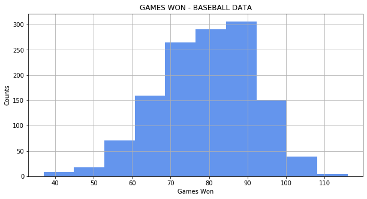

```python
baseball_1960_2010['Games_Won'].hist(figsize=(10,5),bins = 10, color='cornflowerblue')
plt.title('GAMES WON - BASEBALL DATA')
plt.ylabel('Counts')
plt.xlabel('Games Won')
```

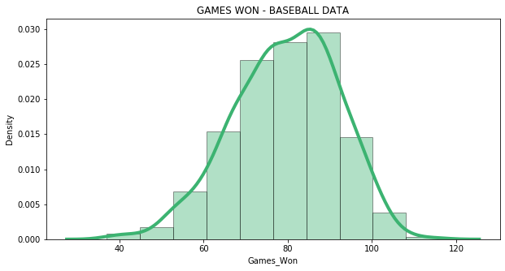

```python
plt.figure(figsize=(10,5))
plt.title('GAMES WON - BASEBALL DATA')
plt.ylabel('Density')
sns.distplot(baseball_1960_2010['Games_Won'], hist=True, kde=True,
             bins=10, color = 'mediumseagreen',
             hist_kws={'edgecolor':'black'},
             kde_kws={'linewidth': 4})
```

*Games Lost*

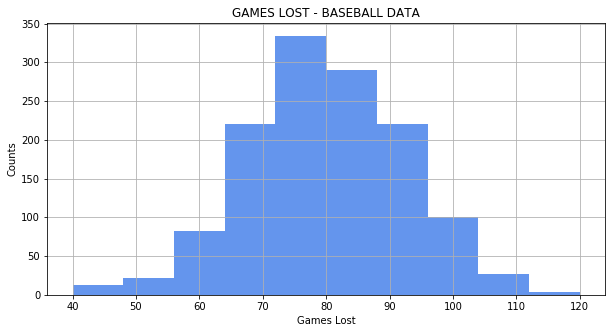

```python
baseball_1960_2010['Games_Lost'].hist(figsize=(10,5),bins = 10, color='cornflowerblue')
plt.title('GAMES LOST - BASEBALL DATA')
plt.ylabel('Counts')
plt.xlabel('Games Lost')
```

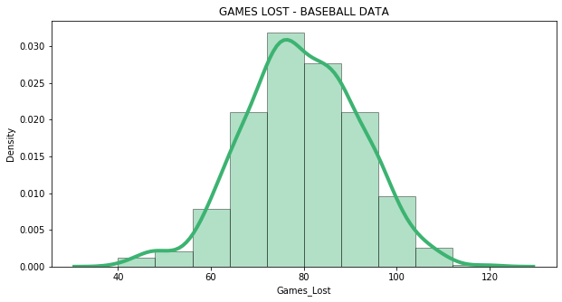

```python
plt.figure(figsize=(10,5))
plt.title('GAMES LOST - BASEBALL DATA')
plt.ylabel('Density')
sns.distplot(baseball_1960_2010['Games_Lost'], hist=True, kde=True,
             bins=10, color = 'mediumseagreen',
             hist_kws={'edgecolor':'black'},
             kde_kws={'linewidth': 4})
```

*Runs Scored*

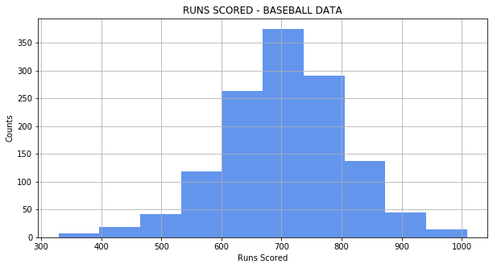

```python
baseball_1960_2010['Runs_Scored'].hist(figsize=(10,5),bins = 10, color='cornflowerblue')
plt.title('RUNS SCORED - BASEBALL DATA')
plt.ylabel('Counts')
plt.xlabel('Runs Scored')
```

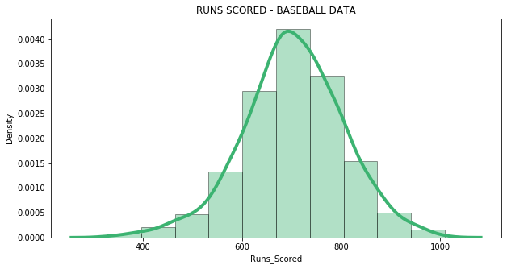

```python
plt.figure(figsize=(10,5))
plt.title('RUNS SCORED - BASEBALL DATA')
plt.ylabel('Density')
sns.distplot(baseball_1960_2010['Runs_Scored'], hist=True, kde=True,
             bins=10, color = 'mediumseagreen',
             hist_kws={'edgecolor':'black'},
             kde_kws={'linewidth': 4})
```

*Home Runs*

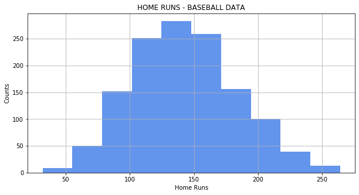

```python
baseball_1960_2010['Home_Runs'].hist(figsize=(10,5),bins = 10, color='cornflowerblue')
plt.title('HOME RUNS - BASEBALL DATA')
plt.ylabel('Counts')
plt.xlabel('Home Runs')
```

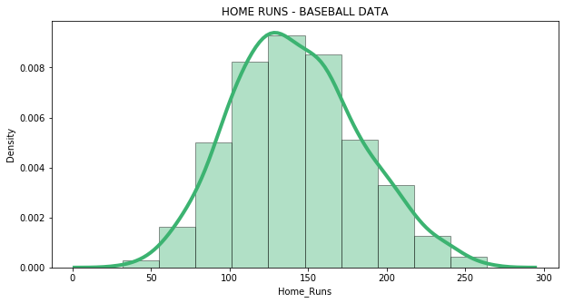

```python
plt.figure(figsize=(10,5))
plt.title('HOME RUNS - BASEBALL DATA')
plt.ylabel('Density')
sns.distplot(baseball_1960_2010['Home_Runs'], hist=True, kde=True,
             bins=10, color = 'mediumseagreen',
             hist_kws={'edgecolor':'black'},
             kde_kws={'linewidth': 4})
```

*Strike Outs*

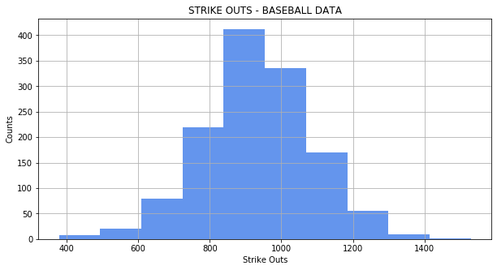

```python
baseball_1960_2010['Strike_Outs'].hist(figsize=(10,5),bins = 10, color='cornflowerblue')
plt.title('STRIKE OUTS - BASEBALL DATA')
plt.ylabel('Counts')
plt.xlabel('Strike Outs')
```

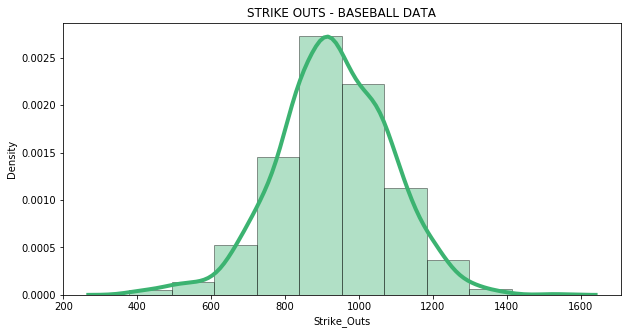

```python
plt.figure(figsize=(10,5))
plt.title('STRIKE OUTS - BASEBALL DATA')
plt.ylabel('Density')
sns.distplot(baseball_1960_2010['Strike_Outs'], hist=True, kde=True,
             bins=10, color = 'mediumseagreen',
             hist_kws={'edgecolor':'black'},
             kde_kws={'linewidth': 4})
```

*Shut Out*

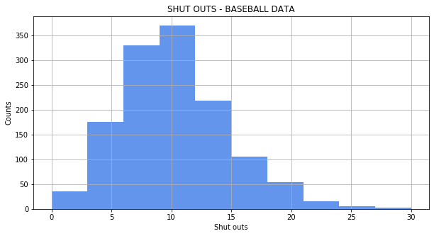

```python
baseball_1960_2010['Shutout'].hist(figsize=(10,5),bins = 10, color='cornflowerblue')
plt.title('SHUT OUTS - BASEBALL DATA')
plt.ylabel('Counts')
plt.xlabel('Shut outs')
```

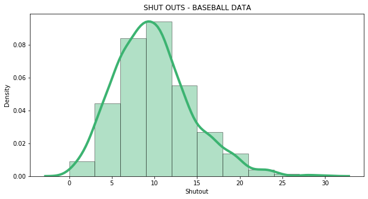

```python
plt.figure(figsize=(10,5))
plt.title('SHUT OUTS - BASEBALL DATA')
plt.ylabel('Density')
sns.distplot(baseball_1960_2010['Shutout'], hist=True, kde=True,
             bins=10, color = 'mediumseagreen',
             hist_kws={'edgecolor':'black'},
             kde_kws={'linewidth': 4})
```

*Home Run Allowed*

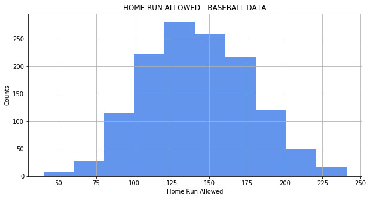

```python
baseball_1960_2010['Home_Run_Allowed'].hist(figsize=(10,5),bins = 10, color='cornflowerblue')
plt.title('HOME RUN ALLOWED - BASEBALL DATA')
plt.ylabel('Counts')
plt.xlabel('Home Run Allowed')
```

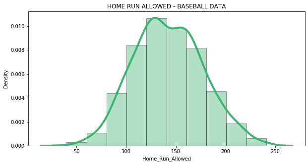

```python
plt.figure(figsize=(10,5))
plt.title('HOME RUN ALLOWED - BASEBALL DATA')
plt.ylabel('Density')
sns.distplot(baseball_1960_2010['Home_Run_Allowed'], hist=True, kde=True,
             bins=10, color = 'mediumseagreen',
             hist_kws={'edgecolor':'black'},
             kde_kws={'linewidth': 4})
```

*Errors*

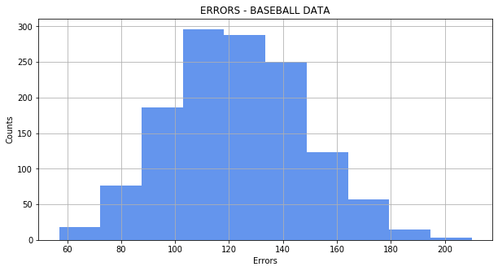

```python
baseball_1960_2010['Errors'].hist(figsize=(10,5),bins = 10, color='cornflowerblue')
plt.title('ERRORS - BASEBALL DATA')
plt.ylabel('Counts')
plt.xlabel('Errors')
```

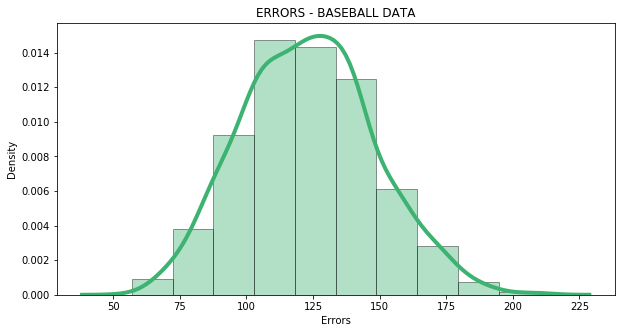

```python
plt.figure(figsize=(10,5))
plt.title('ERRORS - BASEBALL DATA')
plt.ylabel('Density')
sns.distplot(baseball_1960_2010['Errors'], hist=True, kde=True,
             bins=10, color = 'mediumseagreen',
             hist_kws={'edgecolor':'black'},
             kde_kws={'linewidth': 4})
```

**c) Show a boxplot for each of the 8 variables**

*Games Won*

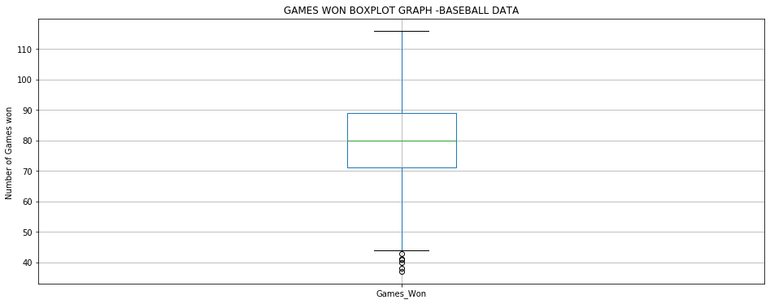

```python
boxplot=baseball_1960_2010.boxplot(column=['Games_Won'],figsize=(16,6))
plt.title('GAMES WON BOXPLOT GRAPH -BASEBALL DATA')
plt.ylabel('Number of Games won ')
```

*Games Lost*

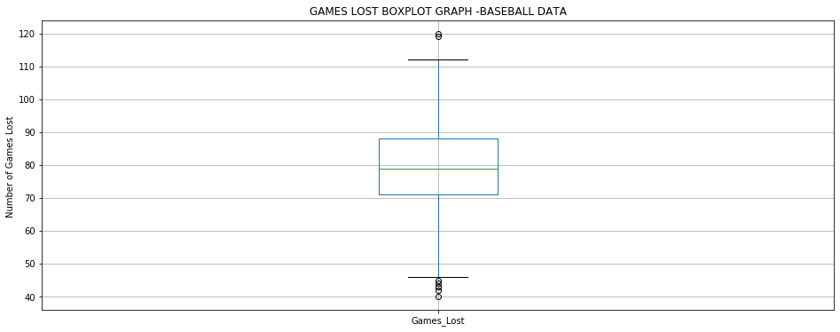

```python
boxplot=baseball_1960_2010.boxplot(column=['Games_Lost'],figsize=(16,6))
plt.title('GAMES LOST BOXPLOT GRAPH -BASEBALL DATA')
plt.ylabel('Number of Games Lost ')
```

*Run Scored*

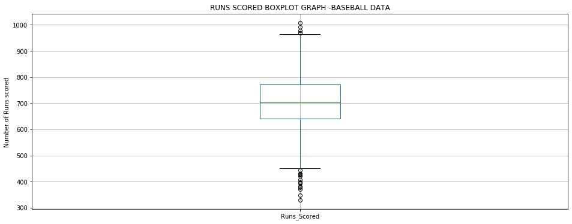

```python
boxplot=baseball_1960_2010.boxplot(column=['Runs_Scored'],figsize=(16,6))
plt.title('RUNS SCORED BOXPLOT GRAPH -BASEBALL DATA')
plt.ylabel('Number of Runs scored ')
```

*Home Runs*

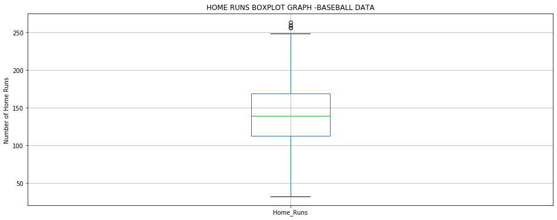

```python
boxplot=baseball_1960_2010.boxplot(column=['Home_Runs'],figsize=(16,6))
plt.title('HOME RUNS BOXPLOT GRAPH -BASEBALL DATA')
plt.ylabel('Number of Home Runs ')
```

*Strike Outs*

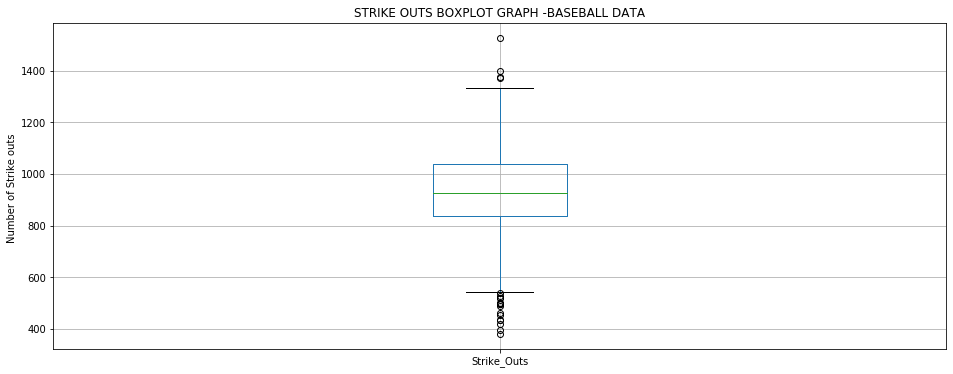

```python
boxplot=baseball_1960_2010.boxplot(column=['Strike_Outs'],figsize=(16,6))
plt.title('STRIKE OUTS BOXPLOT GRAPH -BASEBALL DATA')
plt.ylabel('Number of Strike outs ')
```

*Shut Outs*

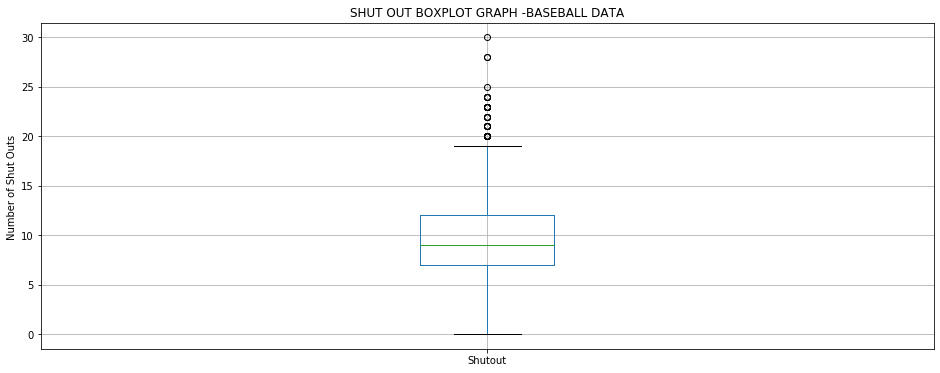

```python
boxplot=baseball_1960_2010.boxplot(column=['Shutout'],figsize=(16,6))
plt.title('SHUT OUT BOXPLOT GRAPH -BASEBALL DATA')
plt.ylabel('Number of Shut Outs ')
```

*Home Run Allowed*

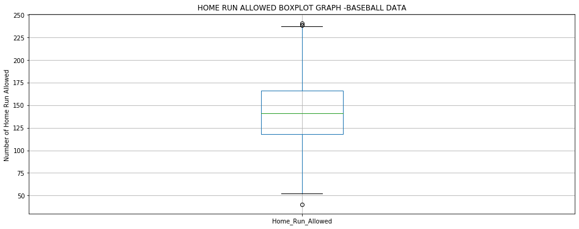

```python
boxplot=baseball_1960_2010.boxplot(column=['Home_Run_Allowed'],figsize=(16,6))
plt.title('HOME RUN ALLOWED BOXPLOT GRAPH -BASEBALL DATA')
plt.ylabel('Number of Home Run Allowed ')
```

*Errors*

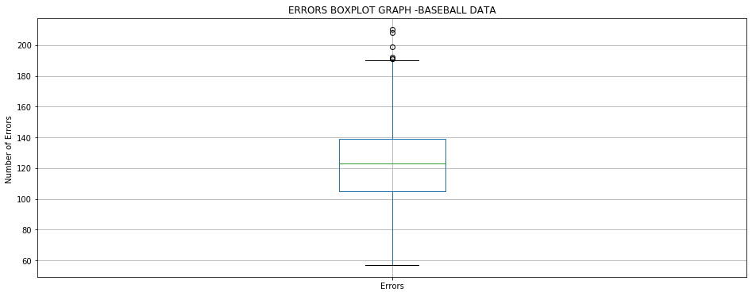

```python
boxplot=baseball_1960_2010.boxplot(column=['Errors'],figsize=(16,6))
plt.title('ERRORS BOXPLOT GRAPH -BASEBALL DATA')
plt.ylabel('Number of Errors ')
```

**d) Comment on the visual shape of the distribution of each variable**

**Is it symmetric?**

**Is there a single mode?**

**Is it narrow or wide?**

**Are there many outliers?**

1) Games Won

*We can see a wide histogram that is left - skewed with a single mode where Mean<Median<Mode. There are teams that won less games than the average and they produce the outliers show at the boxplot*

2) Games Lost

*We can see a wide histogram that is in appereance symmetric with a single mode . There are outliers up and down giving a wide shape to the histogram.*

3) Run Scored

*We can see a wide histogram that looks like left - skewed with a single mode where Mean<Median<Mode. There are teams that Run Scored less than the average and they produce the outliers show at the boxplot*

4) Home Runs

*We can see a wide histogram that is likely right - skewed with a single mode where Mean>Median>Mode. There are teams that made more Home runs than the average and they produce the outliers show at the boxplot*

6) Shut Outs

*We can see a wide histogram that is likely right - skewed with a single mode where Mean>Median>Mode. There are teams that made more Shut Outs than the average and they produce the outliers above as show at the boxplot*

7) Home Run Allowed

*We can see a wide histogram that is in appereance symmetric with a single mode . There are some outliers up and down giving a wide shape to the histogram.*

**e) Comment on the validity of the assumption that each of the 8 variables is normally distributed.**

Game Won

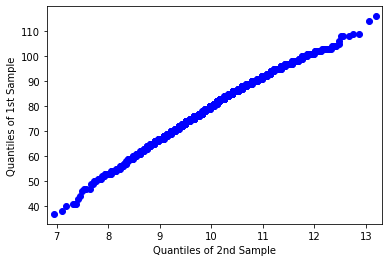

```python
x = baseball_1960_2010['Games_Won']
y = np.random.normal(10, 1, size=10000)
pp_x = sm.ProbPlot(x)
pp_y = sm.ProbPlot(y)
qqplot_2samples(pp_x, pp_y)
plt.show()
```

*We can see an almost straight line , but watching the histogram it is lightly left - skewed .*

Game Lost

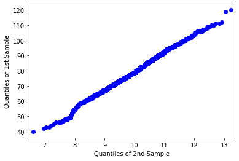

```python
x = baseball_1960_2010['Games_Lost']
y = np.random.normal(10, 1, size=10000)
pp_x = sm.ProbPlot(x)
pp_y = sm.ProbPlot(y)
qqplot_2samples(pp_x, pp_y)
plt.show()
```

*We can see an straight line with fat tails following a normal distribution.*

Run Scored

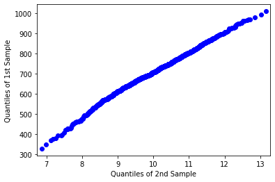

```python
x = baseball_1960_2010['Runs_Scored']
y = np.random.normal(10, 1, size=10000)
pp_x = sm.ProbPlot(x)
pp_y = sm.ProbPlot(y)
qqplot_2samples(pp_x, pp_y)
plt.show()
```

*We can see an almost straight line , but watching the histogram it is lightly left - skewed .*

Home Runs

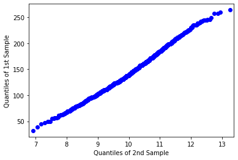

```python
x = baseball_1960_2010['Home_Runs']
y = np.random.normal(10, 1, size=10000)
pp_x = sm.ProbPlot(x)
pp_y = sm.ProbPlot(y)
qqplot_2samples(pp_x, pp_y)
plt.show()
```

*We can see an almost straight line , but watching the histogram it is lightly right - skewed .*

Strike Outs

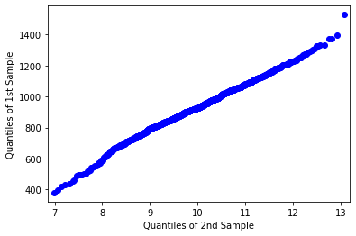

```python
x = baseball_1960_2010['Strike_Outs']
y = np.random.normal(10, 1, size=10000)
pp_x = sm.ProbPlot(x)
pp_y = sm.ProbPlot(y)
qqplot_2samples(pp_x, pp_y)
plt.show()
```

*We can see an almost straight line , but watching the histogram it is lightly left - skewed .*

Shut Outs

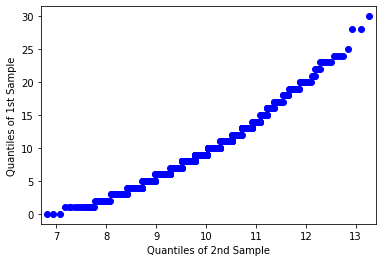

```python
x = baseball_1960_2010['Shutout']
y = np.random.normal(10, 1, size=10000)
pp_x = sm.ProbPlot(x)
pp_y = sm.ProbPlot(y)
qqplot_2samples(pp_x, pp_y)
plt.show()
```

*We can see a line going up and watching the histogram it is right - skewed .*

Home Run Allowed

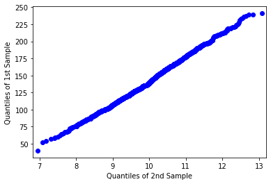

```python
x = baseball_1960_2010['Home_Run_Allowed']
y = np.random.normal(10, 1, size=10000)
pp_x = sm.ProbPlot(x)
pp_y = sm.ProbPlot(y)
qqplot_2samples(pp_x, pp_y)
plt.show()
```

*We can see an straight line with fat tails following a normal distribution*

Errors

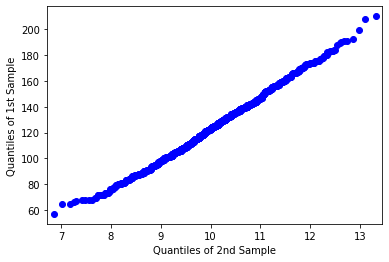

```python
x = baseball_1960_2010['Errors']
y = np.random.normal(10, 1, size=10000)
pp_x = sm.ProbPlot(x)
pp_y = sm.ProbPlot(y)
qqplot_2samples(pp_x, pp_y)
plt.show()
```

*We can see an almost straight line , but watching the histogram it is lightly left - skewed*

## 3) CORRELATION ANALYSIS

**Do a correlation analysis for the following pairs of fields for the complete data spanning 1960 to 2010**

**a) Games Won vs Runs Scored**

```python
baseball_1960_2010[['Games_Won','Runs_Scored']].corr(method = 'pearson')
```

|  | Games_Won | Runs_Scored |
| --- | --- | --- |
| Games_Won | 1.000000 | 0.595828 |
| Runs_Scored | 0.595828 | 1.000000 |

```python
baseball_1960_2010[['Games_Won','Runs_Scored']].corr(method = 'spearman')
```

|  | Games_Won | Runs_Scored |
| --- | --- | --- |
| Games_Won | 1.000000 | 0.555276 |
| Runs_Scored | 0.555276 | 1.000000 |

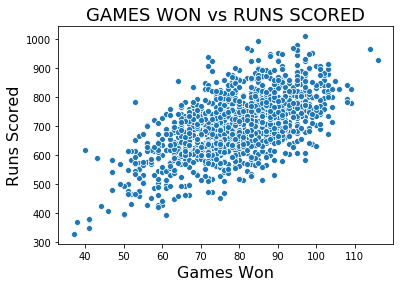

```python
sns.scatterplot('Games_Won','Runs_Scored',data=baseball_1960_2010)
plt.title('GAMES WON vs RUNS SCORED', fontsize=18)
plt.ylabel('Runs Scored', fontsize=16)
plt.xlabel('Games Won', fontsize=16)
```

**b) Games Won vs Runs Against**

```python
baseball_1960_2010[['Games_Won','Runs_Against']].corr(method = 'pearson')
```

|  | Games_Won | Runs_Against |
| --- | --- | --- |
| Games_Won | 1.000000 | -0.248158 |
| Runs_Against | -0.248158 | 1.000000 |

```python
baseball_1960_2010[['Games_Won','Runs_Against']].corr(method = 'spearman')
```

|  | Games_Won | Runs_Against |
| --- | --- | --- |
| Games_Won | 1.000000 | -0.357522 |
| Runs_Against | -0.357522 | 1.000000 |

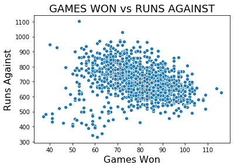

```python
sns.scatterplot('Games_Won','Runs_Against',data=baseball_1960_2010)
plt.title('GAMES WON vs RUNS AGAINST', fontsize=18)
plt.ylabel('Runs Against', fontsize=16)
plt.xlabel('Games Won', fontsize=16)
```

**c) Games Won vs (Runs Scored minus Runs Against)**

```python
baseball_1960_2010['Score_against'] = baseball_1960_2010['Runs_Scored'] - baseball_1960_2010['Runs_Against']
baseball_1960_2010.head(10)
```

| Year | League | Team | Franchise | Division | Final_Standing | Games_Played | Unnamed: 7 | Games_Won | Games_Lost | Unnamed: 10 | ... | Home_Run_Allowed | Walks_Allowed | Strikeouts_Allowed | Errors | Double_Plays | Fielding_Percentage | Team_Name | Home_Ball_Park | Attendance | Score_against |
| --- | --- | --- | --- | --- | --- | --- | --- | --- | --- | --- | --- | --- | --- | --- | --- | --- | --- | --- | --- | --- | --- |
| 1960 | AL | BAL | BAL | NaN | 2 | 154 | 77.0 | 89 | 65 | NaN | ... | 117 | 552 | 785 | 107 | 172.0 | 0.98 | Baltimore Orioles | Memorial Stadium | 1187849.0 | 76 |
| 1960 | AL | BOS | BOS | NaN | 7 | 154 | 77.0 | 65 | 89 | NaN | ... | 127 | 580 | 767 | 140 | 156.0 | 0.97 | Boston Red Sox | Fenway Park II | 1129866.0 | -117 |
| 1960 | AL | CHA | CHW | NaN | 3 | 154 | 77.0 | 87 | 67 | NaN | ... | 127 | 533 | 695 | 109 | 175.0 | 0.98 | Chicago White Sox | Comiskey Park | 1644460.0 | 124 |
| 1960 | NL | CHN | CHC | NaN | 7 | 156 | 79.0 | 60 | 94 | NaN | ... | 152 | 565 | 805 | 143 | 133.0 | 0.97 | Chicago Cubs | Wrigley Field | 809770.0 | -142 |
| 1960 | NL | CIN | CIN | NaN | 6 | 154 | 77.0 | 67 | 87 | NaN | ... | 134 | 442 | 740 | 125 | 155.0 | 0.97 | Cincinnati Reds | Crosley Field | 663486.0 | -52 |
| 1960 | AL | CLE | CLE | NaN | 4 | 154 | 77.0 | 76 | 78 | NaN | ... | 161 | 636 | 771 | 126 | 165.0 | 0.97 | Cleveland Indians | Cleveland Stadium | 950985.0 | -26 |
| 1960 | AL | DET | DET | NaN | 6 | 154 | 77.0 | 71 | 83 | NaN | ... | 141 | 474 | 824 | 137 | 138.0 | 0.97 | Detroit Tigers | Briggs Stadium | 1167669.0 | -11 |
| 1960 | AL | KC1 | OAK | NaN | 8 | 155 | 78.0 | 58 | 96 | NaN | ... | 160 | 525 | 664 | 127 | 149.0 | 0.97 | Kansas City Athletics | Municipal Stadium I | 774944.0 | -141 |
| 1960 | NL | LAN | LAD | NaN | 4 | 154 | 77.0 | 82 | 72 | NaN | ... | 154 | 564 | 1122 | 124 | 142.0 | 0.97 | Los Angeles Dodgers | Los Angeles Memorial Coliseum | 2253887.0 | 69 |
| 1960 | NL | ML1 | ATL | NaN | 2 | 154 | 77.0 | 88 | 66 | NaN | ... | 130 | 518 | 807 | 139 | 137.0 | 0.97 | Milwaukee Braves | County Stadium | 1497799.0 | 66 |

10 rows × 43 columns

```python
baseball_1960_2010[['Games_Won','Score_against']].corr(method = 'pearson')
```

|  | Games_Won | Score_against |
| --- | --- | --- |
| Games_Won | 1.000000 | 0.850411 |
| Score_against | 0.850411 | 1.000000 |

```python
baseball_1960_2010[['Games_Won','Score_against']].corr(method = 'spearman')
```

|  | Games_Won | Score_against |
| --- | --- | --- |
| Games_Won | 1.000000 | 0.873039 |
| Score_against | 0.873039 | 1.000000 |

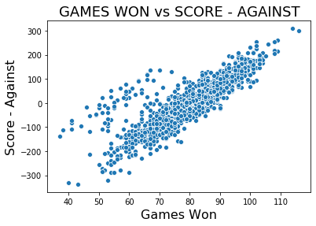

```python
sns.scatterplot('Games_Won','Score_against',data=baseball_1960_2010)
plt.title('GAMES WON vs SCORE - AGAINST', fontsize=18)
plt.ylabel('Score - Against', fontsize=16)
plt.xlabel('Games Won', fontsize=16)
```

**d) Games Lost vs Runs Scored**

```python
baseball_1960_2010[['Games_Lost','Runs_Scored']].corr(method = 'spearman')
```

|  | Games_Lost | Runs_Scored |
| --- | --- | --- |
| Games_Lost | 1.000000 | -0.326352 |
| Runs_Scored | -0.326352 | 1.000000 |

```python
baseball_1960_2010[['Games_Lost','Runs_Scored']].corr(method = 'pearson')
```

|  | Games_Lost | Runs_Scored |
| --- | --- | --- |
| Games_Lost | 1.000000 | -0.226772 |
| Runs_Scored | -0.226772 | 1.000000 |

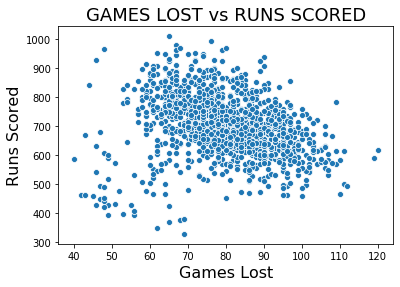

```python
sns.scatterplot('Games_Lost','Runs_Scored',data=baseball_1960_2010)
plt.title('GAMES LOST vs RUNS SCORED', fontsize=18)
plt.ylabel('Runs Scored', fontsize=16)
plt.xlabel('Games Lost', fontsize=16)
```

**e) Games Lost vs Runs Against**

```python
baseball_1960_2010[['Games_Lost','Runs_Against']].corr(method = 'pearson')
```

|  | Games_Lost | Runs_Against |
| --- | --- | --- |
| Games_Lost | 1.000000 | 0.611177 |
| Runs_Against | 0.611177 | 1.000000 |

```python
baseball_1960_2010[['Games_Lost','Runs_Against']].corr(method = 'spearman')
```

|  | Games_Lost | Runs_Against |
| --- | --- | --- |
| Games_Lost | 1.000000 | 0.579854 |
| Runs_Against | 0.579854 | 1.000000 |

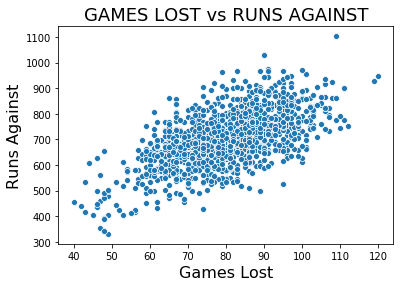

```python
sns.scatterplot('Games_Lost','Runs_Against',data=baseball_1960_2010)
plt.title('GAMES LOST vs RUNS AGAINST', fontsize=18)
plt.ylabel('Runs Against', fontsize=16)
plt.xlabel('Games Lost', fontsize=16)
```

**f) Games Lost vs (Runs Scored minus Runs Against**

```python
baseball_1960_2010[['Games_Lost','Score_against']].corr(method = 'pearson')
```

|  | Games_Lost | Score_against |
| --- | --- | --- |
| Games_Lost | 1.000000 | -0.849358 |
| Score_against | -0.849358 | 1.000000 |

```python
baseball_1960_2010[['Games_Lost','Score_against']].corr(method = 'spearman')
```

|  | Games_Lost | Score_against |
| --- | --- | --- |
| Games_Lost | 1.00000 | -0.86804 |
| Score_against | -0.86804 | 1.00000 |

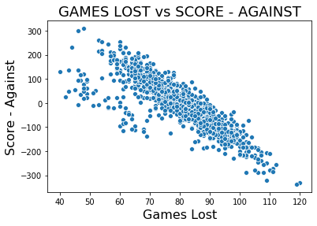

```python
sns.scatterplot('Games_Lost','Score_against',data=baseball_1960_2010)
plt.title('GAMES LOST vs SCORE - AGAINST', fontsize=18)
plt.ylabel('Score - Against', fontsize=16)
plt.xlabel('Games Lost', fontsize=16)
```

**g) Provide an interpretation and commentary for your analysis.**

*We can see that there are two pair of fields where the correlation is quite strong :*

```
- Game Won vs (Runs score minus runs against)  = 0.85 pearson (positive)
                                               = 0.87 spearman(positive)
- Game Lost vs (Runs score minus runs against) = -0.85 pearson(negative)
                                               = -0.87 spearman(negative)
```

*There are other two variables that have relative impact on the game to lost or win.*

```
 - Game Won vs Runs score = 0.59 pearson (positive)
                          = 0.55 spearman(positive)
 - Game Lost vs Runs against = 0.61 pearson (positive)
                             = 0.58 spearman (positive)
```

*We can see that these two variables ( Runs score , Runs against) could have a determinant impact on the strategy of the game. The rest of the pairs of fields has a very low correlation so , the impact on the game is very low or null.*

## 4) LINEAR REGRESSION MODELS

**Create a multiple linear regression model for each of the 4 time periods noted above and select the independent variables that are good predictors of games won.**

**Keep the model as simple as possible**

**Try combinations of offensive and defensive fields as independent variables.**

**a)Period 1 : before 1920**

```python
baseball_before_1920=baseball.loc['1871':'1919']
baseball_before_1920
```

| Year | League | Team | Franchise | Division | Final_Standing | Games_Played | Unnamed: 7 | Games_Won | Games_Lost | Unnamed: 10 | ... | Hits_Allowed | Home_Run_Allowed | Walks_Allowed | Strikeouts_Allowed | Errors | Double_Plays | Fielding_Percentage | Team_Name | Home_Ball_Park | Attendance |
| --- | --- | --- | --- | --- | --- | --- | --- | --- | --- | --- | --- | --- | --- | --- | --- | --- | --- | --- | --- | --- | --- |
| 1871 | NaN | BS1 | BNA | NaN | 3 | 31 | NaN | 20 | 10 | NaN | ... | 367 | 2 | 42 | 23 | 225 | NaN | 0.83 | Boston Red Stockings | South End Grounds I | NaN |
| 1871 | NaN | CH1 | CNA | NaN | 2 | 28 | NaN | 19 | 9 | NaN | ... | 308 | 6 | 28 | 22 | 218 | NaN | 0.82 | Chicago White Stockings | Union Base-Ball Grounds | NaN |
| 1871 | NaN | CL1 | CFC | NaN | 8 | 29 | NaN | 10 | 19 | NaN | ... | 346 | 13 | 53 | 34 | 223 | NaN | 0.81 | Cleveland Forest Citys | National Association Grounds | NaN |
| 1871 | NaN | FW1 | KEK | NaN | 7 | 19 | NaN | 7 | 12 | NaN | ... | 261 | 5 | 21 | 17 | 163 | NaN | 0.80 | Fort Wayne Kekiongas | Hamilton Field | NaN |
| 1871 | NaN | NY2 | NNA | NaN | 5 | 33 | NaN | 16 | 17 | NaN | ... | 373 | 7 | 42 | 22 | 227 | NaN | 0.83 | New York Mutuals | Union Grounds (Brooklyn) | NaN |
| ... | ... | ... | ... | ... | ... | ... | ... | ... | ... | ... | ... | ... | ... | ... | ... | ... | ... | ... | ... | ... | ... |
| 1919 | NL | PHI | PHI | NaN | 8 | 138 | 71.0 | 47 | 90 | NaN | ... | 1391 | 40 | 408 | 397 | 219 | 112.0 | 0.96 | Philadelphia Phillies | Baker Bowl | 240424.0 |
| 1919 | NL | PIT | PIT | NaN | 4 | 139 | 70.0 | 71 | 68 | NaN | ... | 1113 | 23 | 263 | 391 | 160 | 89.0 | 0.96 | Pittsburgh Pirates | Forbes Field | 276810.0 |
| 1919 | AL | SLA | BAL | NaN | 5 | 140 | 70.0 | 67 | 72 | NaN | ... | 1255 | 35 | 421 | 415 | 214 | 98.0 | 0.96 | St. Louis Browns | Sportsman's Park IV | 349350.0 |
| 1919 | NL | SLN | STL | NaN | 7 | 138 | 69.0 | 54 | 83 | NaN | ... | 1146 | 25 | 415 | 414 | 217 | 112.0 | 0.96 | St. Louis Cardinals | Robison Field | 167059.0 |
| 1919 | AL | WS1 | MIN | NaN | 7 | 142 | 72.0 | 56 | 84 | NaN | ... | 1237 | 20 | 451 | 536 | 227 | 86.0 | 0.96 | Washington Senators | Griffith Stadium I | 234096.0 |

703 rows × 42 columns

```python
pd.set_option('display.max_columns', None)
baseball_before_1920.head()
```

| Year | League | Team | Franchise | Division | Final_Standing | Games_Played | Unnamed: 7 | Games_Won | Games_Lost | Unnamed: 10 | Unnamed: 11 | League_Win | World_Series | Runs_Scored | At_Bats | Hits | Doubles | Triples | Home_Runs | Walks | Strike_Outs | Stolen_Bases | Caught_Stealing | Hit_By_Pitch | Sacrifice_Fly | Runs_Against | Earned_Runs | Earned_Run_Average | Complete_Games | … |
| --- | --- | --- | --- | --- | --- | --- | --- | --- | --- | --- | --- | --- | --- | --- | --- | --- | --- | --- | --- | --- | --- | --- | --- | --- | --- | --- | --- | --- | --- | --- |
| 1871 | NaN | BS1 | BNA | NaN | 3 | 31 | NaN | 20 | 10 | NaN | NaN | False | NaN | 401 | 1372 | 426 | 70 | 37 | 3 | 60 | 19.0 | 73.0 | NaN | NaN | NaN | 303 | 109 | 3.55 | 22 | … |
| 1871 | NaN | CH1 | CNA | NaN | 2 | 28 | NaN | 19 | 9 | NaN | NaN | False | NaN | 302 | 1196 | 323 | 52 | 21 | 10 | 60 | 22.0 | 69.0 | NaN | NaN | NaN | 241 | 77 | 2.76 | 25 | … |
| 1871 | NaN | CL1 | CFC | NaN | 8 | 29 | NaN | 10 | 19 | NaN | NaN | False | NaN | 249 | 1186 | 328 | 35 | 40 | 7 | 26 | 25.0 | 18.0 | NaN | NaN | NaN | 341 | 116 | 4.11 | 23 | … |
| 1871 | NaN | FW1 | KEK | NaN | 7 | 19 | NaN | 7 | 12 | NaN | NaN | False | NaN | 137 | 746 | 178 | 19 | 8 | 2 | 33 | 9.0 | 16.0 | NaN | NaN | NaN | 243 | 97 | 5.17 | 19 | … |
| 1871 | NaN | NY2 | NNA | NaN | 5 | 33 | NaN | 16 | 17 | NaN | NaN | False | NaN | 302 | 1404 | 403 | 43 | 21 | 1 | 33 | 15.0 | 46.0 | NaN | NaN | NaN | 313 | 121 | 3.72 | 32 | … |

```python
period1 = smf.ols(formula='Games_Won ~ Runs_Scored + At_Bats + Hits + Doubles + Triples + Home_Runs + Walks + Strike_Outs + Stolen_Bases + Runs_Against +Earned_Runs + Earned_Run_Average + Complete_Games + Shutout + Saves + Infield_Put_Outs + Hits_Allowed + Home_Run_Allowed + Strikeouts_Allowed + Errors', data=baseball_before_1920).fit()
period1.params
```

```
Intercept            -7.409097
Runs_Scored           0.083708
At_Bats              -0.017414
Hits                  0.001749
Doubles               0.017280
Triples               0.008804
Home_Runs             0.004749
Walks                -0.000186
Strike_Outs          -0.013991
Stolen_Bases         -0.005491
Runs_Against         -0.060905
Earned_Runs          -0.016614
Earned_Run_Average    1.839158
Complete_Games        0.149988
Shutout               0.290882
Saves                 0.460201
Infield_Put_Outs      0.034669
Hits_Allowed         -0.003811
Home_Run_Allowed      0.019212
Strikeouts_Allowed    0.003395
Errors                0.000273
dtype: float64
```

**b) Period 2: 1920 to 1959**

```python
baseball_1920_1959=baseball.loc['1920':'1959']
baseball_1920_1959.head()
```

| Year | League | Team | Franchise | Division | Final_Standing | Games_Played | Unnamed: 7 | Games_Won | Games_Lost | Unnamed: 10 | Unnamed: 11 | League_Win | World_Series | Runs_Scored | At_Bats | Hits | Doubles | Triples | Home_Runs | Walks | Strike_Outs | Stolen_Bases | Caught_Stealing | Hit_By_Pitch | Sacrifice_Fly | Runs_Against | Earned_Runs | Earned_Run_Average | Complete_Games | … |
| --- | --- | --- | --- | --- | --- | --- | --- | --- | --- | --- | --- | --- | --- | --- | --- | --- | --- | --- | --- | --- | --- | --- | --- | --- | --- | --- | --- | --- | --- | --- |
| 1920 | AL | BOS | BOS | NaN | 5 | 154 | 76.0 | 72 | 81 | NaN | NaN | False | False | 650 | 5199 | 1397 | 216 | 71 | 22 | 533 | 429.0 | 98.0 | 111.0 | NaN | NaN | 698 | 592 | 3.82 | 92 | … |
| 1920 | NL | BRO | LAD | NaN | 1 | 155 | 78.0 | 93 | 61 | NaN | NaN | True | False | 660 | 5399 | 1493 | 205 | 99 | 28 | 359 | 391.0 | 70.0 | 80.0 | NaN | NaN | 528 | 415 | 2.62 | 89 | … |
| 1920 | NL | BSN | ATL | NaN | 7 | 153 | 74.0 | 62 | 90 | NaN | NaN | False | False | 523 | 5218 | 1358 | 168 | 86 | 23 | 385 | 488.0 | 88.0 | 98.0 | NaN | NaN | 670 | 545 | 3.54 | 93 | … |
| 1920 | AL | CHA | CHW | NaN | 2 | 154 | 77.0 | 96 | 58 | NaN | NaN | False | False | 794 | 5328 | 1574 | 263 | 98 | 37 | 471 | 353.0 | 112.0 | 96.0 | NaN | NaN | 665 | 553 | 3.59 | 109 | … |
| 1920 | NL | CHN | CHC | NaN | 5 | 154 | 77.0 | 75 | 79 | NaN | NaN | False | False | 619 | 5117 | 1350 | 223 | 67 | 34 | 428 | 421.0 | 115.0 | 129.0 | NaN | NaN | 635 | 504 | 3.27 | 95 | … |

```python
period2 = smf.ols(formula='Games_Won ~ Runs_Scored + At_Bats + Hits + Doubles + Triples + Home_Runs + Walks + Strike_Outs + Stolen_Bases + Runs_Against +Earned_Runs + Earned_Run_Average + Complete_Games + Shutout + Saves + Infield_Put_Outs + Hits_Allowed + Home_Run_Allowed + Strikeouts_Allowed + Errors', data=baseball_1920_1959).fit()
period2.params
```

```
Intercept            -151.627537
Runs_Scored             0.085199
At_Bats                -0.014181
Hits                    0.008801
Doubles                 0.011921
Triples                 0.016868
Home_Runs              -0.005235
Walks                  -0.004030
Strike_Outs            -0.001276
Stolen_Bases           -0.020502
Runs_Against           -0.078548
Earned_Runs            -0.234614
Earned_Run_Average     36.479257
Complete_Games          0.130029
Shutout                 0.057469
Saves                   0.308981
Infield_Put_Outs        0.066116
Hits_Allowed           -0.002234
Home_Run_Allowed        0.010757
Strikeouts_Allowed      0.001868
Errors                 -0.007678
dtype: float64
```

**c) Period 3: 1960 to 1989**

```python
baseball_1960_1989=baseball.loc['1960':'1989']
baseball_1960_1989.head()
```

| Year | League | Team | Franchise | Division | Final_Standing | Games_Played | Unnamed: 7 | Games_Won | Games_Lost | Unnamed: 10 | Unnamed: 11 | League_Win | World_Series | Runs_Scored | At_Bats | Hits | Doubles | Triples | Home_Runs | Walks | Strike_Outs | Stolen_Bases | Caught_Stealing | Hit_By_Pitch | Sacrifice_Fly | Runs_Against | Earned_Runs | Earned_Run_Average | Complete_Games | … |
| --- | --- | --- | --- | --- | --- | --- | --- | --- | --- | --- | --- | --- | --- | --- | --- | --- | --- | --- | --- | --- | --- | --- | --- | --- | --- | --- | --- | --- | --- | --- |
| 1960 | AL | BAL | BAL | NaN | 2 | 154 | 77.0 | 89 | 65 | NaN | NaN | False | False | 682 | 5170 | 1307 | 206 | 33 | 123 | 596 | 801.0 | 37.0 | 24.0 | NaN | NaN | 606 | 538 | 3.52 | 48 | … |
| 1960 | AL | BOS | BOS | NaN | 7 | 154 | 77.0 | 65 | 89 | NaN | NaN | False | False | 658 | 5215 | 1359 | 234 | 32 | 124 | 570 | 798.0 | 34.0 | 28.0 | NaN | NaN | 775 | 699 | 4.62 | 34 | … |
| 1960 | AL | CHA | CHW | NaN | 3 | 154 | 77.0 | 87 | 67 | NaN | NaN | False | False | 741 | 5191 | 1402 | 242 | 38 | 112 | 567 | 648.0 | 122.0 | 48.0 | NaN | NaN | 617 | 552 | 3.60 | 42 | … |
| 1960 | NL | CHN | CHC | NaN | 7 | 156 | 79.0 | 60 | 94 | NaN | NaN | False | False | 634 | 5311 | 1293 | 213 | 48 | 119 | 531 | 897.0 | 51.0 | 34.0 | NaN | NaN | 776 | 678 | 4.35 | 36 | … |
| 1960 | NL | CIN | CIN | NaN | 6 | 154 | 77.0 | 67 | 87 | NaN | NaN | False | False | 640 | 5289 | 1324 | 230 | 40 | 140 | 512 | 858.0 | 73.0 | 37.0 | NaN | NaN | 692 | 618 | 4.00 | 33 | … |

```python
period3 = smf.ols(formula='Games_Won ~ Runs_Scored + At_Bats + Hits + Doubles + Triples + Home_Runs + Walks + Strike_Outs + Stolen_Bases + Runs_Against +Earned_Runs + Earned_Run_Average + Complete_Games + Shutout + Saves + Infield_Put_Outs + Hits_Allowed + Home_Run_Allowed + Strikeouts_Allowed + Errors', data=baseball_1960_1989).fit()
period3.params
```

```
Intercept            -12.729140
Runs_Scored            0.084690
At_Bats               -0.035491
Hits                   0.028635
Doubles               -0.002220
Triples                0.010240
Home_Runs              0.010061
Walks                 -0.001679
Strike_Outs            0.000274
Stolen_Bases          -0.002866
Runs_Against          -0.050538
Earned_Runs           -0.039561
Earned_Run_Average     3.349776
Complete_Games         0.141008
Shutout                0.196018
Saves                  0.306784
Infield_Put_Outs       0.050438
Hits_Allowed           0.001209
Home_Run_Allowed       0.000010
Strikeouts_Allowed     0.001286
Errors                -0.024885
dtype: float64
```

**d) Period 4 : 1990 to 2010**

```python
baseball_1990_2010=baseball.loc['1990':'2010']
baseball_1990_2010.head()
```

| Year | League | Team | Franchise | Division | Final_Standing | Games_Played | Unnamed: 7 | Games_Won | Games_Lost | Unnamed: 10 | Unnamed: 11 | League_Win | World_Series | Runs_Scored | At_Bats | Hits | Doubles | Triples | Home_Runs | Walks | Strike_Outs | Stolen_Bases | Caught_Stealing | Hit_By_Pitch | Sacrifice_Fly | Runs_Against | Earned_Runs | Earned_Run_Average | Complete_Games | … |
| --- | --- | --- | --- | --- | --- | --- | --- | --- | --- | --- | --- | --- | --- | --- | --- | --- | --- | --- | --- | --- | --- | --- | --- | --- | --- | --- | --- | --- | --- | --- |
| 1990 | NL | ATL | ATL | W | 6 | 162 | 81.0 | 65 | 97 | False | NaN | False | False | 682 | 5504 | 1376 | 263 | 26 | 162 | 473 | 1010.0 | 92.0 | 55.0 | NaN | NaN | 821 | 727 | 4.58 | 17 | … |
| 1990 | AL | BAL | BAL | E | 5 | 161 | 80.0 | 76 | 85 | False | NaN | False | False | 669 | 5410 | 1328 | 234 | 22 | 132 | 660 | 962.0 | 94.0 | 52.0 | NaN | NaN | 698 | 644 | 4.04 | 10 | … |
| 1990 | AL | BOS | BOS | E | 1 | 162 | 81.0 | 88 | 74 | True | NaN | False | False | 699 | 5516 | 1502 | 298 | 31 | 106 | 598 | 795.0 | 53.0 | 52.0 | NaN | NaN | 664 | 596 | 3.72 | 15 | … |
| 1990 | AL | CAL | ANA | W | 4 | 162 | 81.0 | 80 | 82 | False | NaN | False | False | 690 | 5570 | 1448 | 237 | 27 | 147 | 566 | 1000.0 | 69.0 | 43.0 | NaN | NaN | 706 | 612 | 3.79 | 21 | … |
| 1990 | AL | CHA | CHW | W | 2 | 162 | 80.0 | 94 | 68 | False | NaN | False | False | 682 | 5402 | 1393 | 251 | 44 | 106 | 478 | 903.0 | 140.0 | 90.0 | NaN | NaN | 633 | 581 | 3.61 | 17 | … |

```python
period4 = smf.ols(formula='Games_Won ~ Runs_Scored + At_Bats + Hits + Doubles + Triples + Home_Runs + Walks + Strike_Outs + Stolen_Bases + Runs_Against +Earned_Runs + Earned_Run_Average + Complete_Games + Shutout + Saves + Infield_Put_Outs + Hits_Allowed + Home_Run_Allowed + Strikeouts_Allowed + Errors', data=baseball_1990_2010).fit()
period4.params
```

```
Intercept            -14.316908
Runs_Scored            0.078149
At_Bats               -0.036174
Hits                   0.031622
Doubles               -0.002154
Triples               -0.034648
Home_Runs              0.013826
Walks                 -0.001524
Strike_Outs            0.001597
Stolen_Bases          -0.001389
Runs_Against          -0.030092
Earned_Runs           -0.053664
Earned_Run_Average     3.522177
Complete_Games         0.074009
Shutout                0.175764
Saves                  0.359500
Infield_Put_Outs       0.050227
Hits_Allowed           0.001531
Home_Run_Allowed      -0.009283
Strikeouts_Allowed     0.003374
Errors                -0.044771
dtype: float64
```

**Justify your model in terms of the independent variables you selected**

*First of all we created a model with the variables that could have an impact on winning a game for the four periods. Next step we will analyse the Statistical Significance for the variables and choose which ones have a direct contribution to the model.*

## 5) MODEL VALIDATION

**Evaluate each of your 4 regression models**

**Statistical significance of the overall model**

**Statistical significance of each coefficient, including the intercept**

**Are your independent variables approximately normally distributed?**

**a) Period 1 : before 1920**

**Model 1**

```python
period1.summary()
```

OLS Regression Results

| Dep. Variable: | Games_Won | R-squared: | 0.966 |
| --- | --- | --- | --- |
| Model: | OLS | Adj. R-squared: | 0.964 |
| Method: | Least Squares | F-statistic: | 593.3 |
| Date: | Wed, 15 Jul 2020 | Prob (F-statistic): | 2.73e-292 |
| Time: | 18:32:45 | Log-Likelihood: | -1215.9 |
| No. Observations: | 439 | AIC: | 2474. |
| Df Residuals: | 418 | BIC: | 2559. |
| Df Model: | 20 |  |  |
| Covariance Type: | nonrobust |  |  |

|  | coef | std err | t | P>\|t\| | [0.025 | 0.975] |
| --- | --- | --- | --- | --- | --- | --- |
| Intercept | -7.4091 | 3.336 | -2.221 | 0.027 | -13.967 | -0.851 |
| Runs_Scored | 0.0837 | 0.005 | 15.271 | 0.000 | 0.073 | 0.094 |
| At_Bats | -0.0174 | 0.003 | -5.209 | 0.000 | -0.024 | -0.011 |
| Hits | 0.0017 | 0.005 | 0.325 | 0.745 | -0.009 | 0.012 |
| Doubles | 0.0173 | 0.009 | 1.862 | 0.063 | -0.001 | 0.036 |
| Triples | 0.0088 | 0.013 | 0.679 | 0.498 | -0.017 | 0.034 |
| Home_Runs | 0.0047 | 0.021 | 0.231 | 0.817 | -0.036 | 0.045 |
| Walks | -0.0002 | 0.004 | -0.048 | 0.962 | -0.008 | 0.007 |
| Strike_Outs | -0.0140 | 0.003 | -4.536 | 0.000 | -0.020 | -0.008 |
| Stolen_Bases | -0.0055 | 0.004 | -1.538 | 0.125 | -0.013 | 0.002 |
| Runs_Against | -0.0609 | 0.008 | -7.579 | 0.000 | -0.077 | -0.045 |
| Earned_Runs | -0.0166 | 0.009 | -1.751 | 0.081 | -0.035 | 0.002 |
| Earned_Run_Average | 1.8392 | 0.651 | 2.824 | 0.005 | 0.559 | 3.119 |
| Complete_Games | 0.1500 | 0.019 | 7.973 | 0.000 | 0.113 | 0.187 |
| Shutout | 0.2909 | 0.059 | 4.906 | 0.000 | 0.174 | 0.407 |
| Saves | 0.4602 | 0.084 | 5.454 | 0.000 | 0.294 | 0.626 |
| Infield_Put_Outs | 0.0347 | 0.004 | 9.290 | 0.000 | 0.027 | 0.042 |
| Hits_Allowed | -0.0038 | 0.004 | -0.859 | 0.391 | -0.013 | 0.005 |
| Home_Run_Allowed | 0.0192 | 0.023 | 0.841 | 0.401 | -0.026 | 0.064 |
| Strikeouts_Allowed | 0.0034 | 0.003 | 1.171 | 0.242 | -0.002 | 0.009 |
| Errors | 0.0003 | 0.006 | 0.042 | 0.966 | -0.012 | 0.013 |

| Omnibus: | 0.284 | Durbin-Watson: | 2.052 |
| --- | --- | --- | --- |
| Prob(Omnibus): | 0.867 | Jarque-Bera (JB): | 0.166 |
| Skew: | 0.036 | Prob(JB): | 0.921 |
| Kurtosis: | 3.061 | Cond. No. | 1.15e+05 |

Warnings:  
[1] Standard Errors assume that the covariance matrix of the errors is correctly specified.  
[2] The condition number is large, 1.15e+05. This might indicate that there are  
strong multicollinearity or other numerical problems.

*We can see the R2 and adj R2 are very good numbers, F statistics is far from zero, we can say that the model is in good shape. There are coefficients where the p-value is very high ( more than 0.05), we eliminate them and check for the next model.*

**Model 2**

```python
period12 = smf.ols(formula='Games_Won ~ Runs_Scored + At_Bats + Strike_Outs + Runs_Against + Earned_Run_Average + Complete_Games + Shutout + Saves + Infield_Put_Outs ', data=baseball_before_1920).fit()
period12.params
```

```
Intercept            -0.344138
Runs_Scored           0.086609
At_Bats              -0.016800
Strike_Outs          -0.007529
Runs_Against         -0.068260
Earned_Run_Average    0.665946
Complete_Games        0.140833
Shutout               0.319498
Saves                 0.400946
Infield_Put_Outs      0.031915
dtype: float64
```

```python
period12.summary()
```

OLS Regression Results

| Dep. Variable: | Games_Won | R-squared: | 0.973 |
| --- | --- | --- | --- |
| Model: | OLS | Adj. R-squared: | 0.972 |
| Method: | Least Squares | F-statistic: | 2261. |
| Date: | Wed, 15 Jul 2020 | Prob (F-statistic): | 0.00 |
| Time: | 18:34:10 | Log-Likelihood: | -1615.5 |
| No. Observations: | 583 | AIC: | 3251. |
| Df Residuals: | 573 | BIC: | 3295. |
| Df Model: | 9 |  |  |
| Covariance Type: | nonrobust |  |  |

|  | coef | std err | t | P>\|t\| | [0.025 | 0.975] |
| --- | --- | --- | --- | --- | --- | --- |
| Intercept | -0.3441 | 1.263 | -0.273 | 0.785 | -2.824 | 2.136 |
| Runs_Scored | 0.0866 | 0.002 | 43.986 | 0.000 | 0.083 | 0.090 |
| At_Bats | -0.0168 | 0.002 | -8.195 | 0.000 | -0.021 | -0.013 |
| Strike_Outs | -0.0075 | 0.002 | -4.529 | 0.000 | -0.011 | -0.004 |
| Runs_Against | -0.0683 | 0.003 | -24.472 | 0.000 | -0.074 | -0.063 |
| Earned_Run_Average | 0.6659 | 0.347 | 1.917 | 0.056 | -0.016 | 1.348 |
| Complete_Games | 0.1408 | 0.015 | 9.272 | 0.000 | 0.111 | 0.171 |
| Shutout | 0.3195 | 0.052 | 6.149 | 0.000 | 0.217 | 0.422 |
| Saves | 0.4009 | 0.077 | 5.212 | 0.000 | 0.250 | 0.552 |
| Infield_Put_Outs | 0.0319 | 0.002 | 14.672 | 0.000 | 0.028 | 0.036 |

| Omnibus: | 0.708 | Durbin-Watson: | 2.051 |
| --- | --- | --- | --- |
| Prob(Omnibus): | 0.702 | Jarque-Bera (JB): | 0.653 |
| Skew: | -0.082 | Prob(JB): | 0.722 |
| Kurtosis: | 3.013 | Cond. No. | 4.51e+04 |

Warnings:  
[1] Standard Errors assume that the covariance matrix of the errors is correctly specified.  
[2] The condition number is large, 4.51e+04. This might indicate that there are  
strong multicollinearity or other numerical problems.

**Model 3**

```python
period13 = smf.ols(formula='Games_Won ~ Runs_Scored + At_Bats + Strike_Outs + Runs_Against + Complete_Games + Shutout + Saves + Infield_Put_Outs ', data=baseball_before_1920).fit()
period13.params
```

```
Intercept           1.648306
Runs_Scored         0.087227
At_Bats            -0.018195
Strike_Outs        -0.007932
Runs_Against       -0.064160
Complete_Games      0.136551
Shutout             0.319593
Saves               0.391681
Infield_Put_Outs    0.033100
dtype: float64
```

```python
period13.summary()
```

OLS Regression Results

| Dep. Variable: | Games_Won | R-squared: | 0.972 |
| --- | --- | --- | --- |
| Model: | OLS | Adj. R-squared: | 0.972 |
| Method: | Least Squares | F-statistic: | 2531. |
| Date: | Wed, 15 Jul 2020 | Prob (F-statistic): | 0.00 |
| Time: | 18:34:33 | Log-Likelihood: | -1617.3 |
| No. Observations: | 583 | AIC: | 3253. |
| Df Residuals: | 574 | BIC: | 3292. |
| Df Model: | 8 |  |  |
| Covariance Type: | nonrobust |  |  |

|  | coef | std err | t | P>\|t\| | [0.025 | 0.975] |
| --- | --- | --- | --- | --- | --- | --- |
| Intercept | 1.6483 | 0.719 | 2.293 | 0.022 | 0.236 | 3.060 |
| Runs_Scored | 0.0872 | 0.002 | 44.800 | 0.000 | 0.083 | 0.091 |
| At_Bats | -0.0182 | 0.002 | -9.472 | 0.000 | -0.022 | -0.014 |
| Strike_Outs | -0.0079 | 0.002 | -4.799 | 0.000 | -0.011 | -0.005 |
| Runs_Against | -0.0642 | 0.002 | -35.742 | 0.000 | -0.068 | -0.061 |
| Complete_Games | 0.1366 | 0.015 | 9.068 | 0.000 | 0.107 | 0.166 |
| Shutout | 0.3196 | 0.052 | 6.137 | 0.000 | 0.217 | 0.422 |
| Saves | 0.3917 | 0.077 | 5.090 | 0.000 | 0.241 | 0.543 |
| Infield_Put_Outs | 0.0331 | 0.002 | 15.834 | 0.000 | 0.029 | 0.037 |

| Omnibus: | 0.595 | Durbin-Watson: | 2.058 |
| --- | --- | --- | --- |
| Prob(Omnibus): | 0.743 | Jarque-Bera (JB): | 0.561 |
| Skew: | -0.076 | Prob(JB): | 0.755 |
| Kurtosis: | 3.000 | Cond. No. | 2.50e+04 |

Warnings:  
[1] Standard Errors assume that the covariance matrix of the errors is correctly specified.  
[2] The condition number is large, 2.5e+04. This might indicate that there are  
strong multicollinearity or other numerical problems.

**b) Period 2: 1920 to 1959**

**Model 1**

```python
period2.summary()
```

OLS Regression Results

| Dep. Variable: | Games_Won | R-squared: | 0.935 |
| --- | --- | --- | --- |
| Model: | OLS | Adj. R-squared: | 0.933 |
| Method: | Least Squares | F-statistic: | 442.6 |
| Date: | Wed, 15 Jul 2020 | Prob (F-statistic): | 0.00 |
| Time: | 18:34:51 | Log-Likelihood: | -1738.8 |
| No. Observations: | 640 | AIC: | 3520. |
| Df Residuals: | 619 | BIC: | 3613. |
| Df Model: | 20 |  |  |
| Covariance Type: | nonrobust |  |  |

|  | coef | std err | t | P>\|t\| | [0.025 | 0.975] |
| --- | --- | --- | --- | --- | --- | --- |
| Intercept | -151.6275 | 58.096 | -2.610 | 0.009 | -265.716 | -37.539 |
| Runs_Scored | 0.0852 | 0.006 | 14.242 | 0.000 | 0.073 | 0.097 |
| At_Bats | -0.0142 | 0.003 | -4.718 | 0.000 | -0.020 | -0.008 |
| Hits | 0.0088 | 0.005 | 1.713 | 0.087 | -0.001 | 0.019 |
| Doubles | 0.0119 | 0.007 | 1.818 | 0.070 | -0.001 | 0.025 |
| Triples | 0.0169 | 0.013 | 1.337 | 0.182 | -0.008 | 0.042 |
| Home_Runs | -0.0052 | 0.009 | -0.563 | 0.574 | -0.024 | 0.013 |
| Walks | -0.0040 | 0.003 | -1.282 | 0.200 | -0.010 | 0.002 |
| Strike_Outs | -0.0013 | 0.003 | -0.499 | 0.618 | -0.006 | 0.004 |
| Stolen_Bases | -0.0205 | 0.007 | -2.980 | 0.003 | -0.034 | -0.007 |
| Runs_Against | -0.0785 | 0.011 | -7.013 | 0.000 | -0.101 | -0.057 |
| Earned_Runs | -0.2346 | 0.097 | -2.414 | 0.016 | -0.426 | -0.044 |
| Earned_Run_Average | 36.4793 | 14.630 | 2.493 | 0.013 | 7.748 | 65.210 |
| Complete_Games | 0.1300 | 0.019 | 6.899 | 0.000 | 0.093 | 0.167 |
| Shutout | 0.0575 | 0.051 | 1.116 | 0.265 | -0.044 | 0.159 |
| Saves | 0.3090 | 0.037 | 8.393 | 0.000 | 0.237 | 0.381 |
| Infield_Put_Outs | 0.0661 | 0.015 | 4.550 | 0.000 | 0.038 | 0.095 |
| Hits_Allowed | -0.0022 | 0.004 | -0.609 | 0.543 | -0.009 | 0.005 |
| Home_Run_Allowed | 0.0108 | 0.009 | 1.202 | 0.230 | -0.007 | 0.028 |
| Strikeouts_Allowed | 0.0019 | 0.002 | 0.824 | 0.410 | -0.003 | 0.006 |
| Errors | -0.0077 | 0.010 | -0.780 | 0.436 | -0.027 | 0.012 |

| Omnibus: | 0.632 | Durbin-Watson: | 2.134 |
| --- | --- | --- | --- |
| Prob(Omnibus): | 0.729 | Jarque-Bera (JB): | 0.732 |
| Skew: | -0.045 | Prob(JB): | 0.693 |
| Kurtosis: | 2.860 | Cond. No. | 2.93e+06 |

Warnings:  
[1] Standard Errors assume that the covariance matrix of the errors is correctly specified.  
[2] The condition number is large, 2.93e+06. This might indicate that there are  
strong multicollinearity or other numerical problems.

We can see the R2 and adj R2 are very good numbers, F statistics is far from zero, we can say that the model is in good shape. There are some coefficients where the p-value is high ( more than 0.05). We eliminate them and check for the next model

**Model 2**

```python
period22 = smf.ols(formula='Games_Won ~ Runs_Scored + At_Bats + Stolen_Bases + Runs_Against +Earned_Runs + Earned_Run_Average + Complete_Games + Saves + Infield_Put_Outs ', data=baseball_1920_1959).fit()
period22.params
```

```
Intercept            -151.310079
Runs_Scored             0.089440
At_Bats                -0.006244
Stolen_Bases           -0.011774
Runs_Against           -0.082425
Earned_Runs            -0.223702
Earned_Run_Average     34.794949
Complete_Games          0.138805
Saves                   0.319269
Infield_Put_Outs        0.058204
dtype: float64
```

```python
period22.summary()
```

OLS Regression Results

| Dep. Variable: | Games_Won | R-squared: | 0.932 |
| --- | --- | --- | --- |
| Model: | OLS | Adj. R-squared: | 0.931 |
| Method: | Least Squares | F-statistic: | 955.8 |
| Date: | Wed, 15 Jul 2020 | Prob (F-statistic): | 0.00 |
| Time: | 18:39:23 | Log-Likelihood: | -1752.5 |
| No. Observations: | 640 | AIC: | 3525. |
| Df Residuals: | 630 | BIC: | 3570. |
| Df Model: | 9 |  |  |
| Covariance Type: | nonrobust |  |  |

|  | coef | std err | t | P>\|t\| | [0.025 | 0.975] |
| --- | --- | --- | --- | --- | --- | --- |
| Intercept | -151.3101 | 57.704 | -2.622 | 0.009 | -264.626 | -37.994 |
| Runs_Scored | 0.0894 | 0.002 | 40.082 | 0.000 | 0.085 | 0.094 |
| At_Bats | -0.0062 | 0.002 | -2.855 | 0.004 | -0.011 | -0.002 |
| Stolen_Bases | -0.0118 | 0.006 | -1.967 | 0.050 | -0.024 | -1.8e-05 |
| Runs_Against | -0.0824 | 0.007 | -12.296 | 0.000 | -0.096 | -0.069 |
| Earned_Runs | -0.2237 | 0.095 | -2.351 | 0.019 | -0.411 | -0.037 |
| Earned_Run_Average | 34.7949 | 14.484 | 2.402 | 0.017 | 6.353 | 63.237 |
| Complete_Games | 0.1388 | 0.018 | 7.751 | 0.000 | 0.104 | 0.174 |
| Saves | 0.3193 | 0.037 | 8.700 | 0.000 | 0.247 | 0.391 |
| Infield_Put_Outs | 0.0582 | 0.014 | 4.081 | 0.000 | 0.030 | 0.086 |

| Omnibus: | 0.619 | Durbin-Watson: | 2.170 |
| --- | --- | --- | --- |
| Prob(Omnibus): | 0.734 | Jarque-Bera (JB): | 0.498 |
| Skew: | -0.060 | Prob(JB): | 0.779 |
| Kurtosis: | 3.067 | Cond. No. | 2.72e+06 |

Warnings:  
[1] Standard Errors assume that the covariance matrix of the errors is correctly specified.  
[2] The condition number is large, 2.72e+06. This might indicate that there are  
strong multicollinearity or other numerical problems.

**Period 3: 1960 to 1989**

**Model 1**

```python
period3.summary()
```

OLS Regression Results

| Dep. Variable: | Games_Won | R-squared: | 0.934 |
| --- | --- | --- | --- |
| Model: | OLS | Adj. R-squared: | 0.932 |
| Method: | Least Squares | F-statistic: | 482.2 |
| Date: | Wed, 15 Jul 2020 | Prob (F-statistic): | 0.00 |
| Time: | 18:43:08 | Log-Likelihood: | -1833.0 |
| No. Observations: | 704 | AIC: | 3708. |
| Df Residuals: | 683 | BIC: | 3804. |
| Df Model: | 20 |  |  |
| Covariance Type: | nonrobust |  |  |

|  | coef | std err | t | P>\|t\| | [0.025 | 0.975] |
| --- | --- | --- | --- | --- | --- | --- |
| Intercept | -12.7291 | 19.417 | -0.656 | 0.512 | -50.853 | 25.394 |
| Runs_Scored | 0.0847 | 0.006 | 14.324 | 0.000 | 0.073 | 0.096 |
| At_Bats | -0.0355 | 0.005 | -7.288 | 0.000 | -0.045 | -0.026 |
| Hits | 0.0286 | 0.006 | 4.823 | 0.000 | 0.017 | 0.040 |
| Doubles | -0.0022 | 0.006 | -0.351 | 0.726 | -0.015 | 0.010 |
| Triples | 0.0102 | 0.014 | 0.721 | 0.471 | -0.018 | 0.038 |
| Home_Runs | 0.0101 | 0.008 | 1.285 | 0.199 | -0.005 | 0.025 |
| Walks | -0.0017 | 0.003 | -0.553 | 0.580 | -0.008 | 0.004 |
| Strike_Outs | 0.0003 | 0.002 | 0.162 | 0.872 | -0.003 | 0.004 |
| Stolen_Bases | -0.0029 | 0.004 | -0.813 | 0.417 | -0.010 | 0.004 |
| Runs_Against | -0.0505 | 0.013 | -3.830 | 0.000 | -0.076 | -0.025 |
| Earned_Runs | -0.0396 | 0.036 | -1.101 | 0.271 | -0.110 | 0.031 |
| Earned_Run_Average | 3.3498 | 5.387 | 0.622 | 0.534 | -7.227 | 13.927 |
| Complete_Games | 0.1410 | 0.017 | 8.535 | 0.000 | 0.109 | 0.173 |
| Shutout | 0.1960 | 0.042 | 4.716 | 0.000 | 0.114 | 0.278 |
| Saves | 0.3068 | 0.024 | 12.974 | 0.000 | 0.260 | 0.353 |
| Infield_Put_Outs | 0.0504 | 0.007 | 7.675 | 0.000 | 0.038 | 0.063 |
| Hits_Allowed | 0.0012 | 0.003 | 0.386 | 0.700 | -0.005 | 0.007 |
| Home_Run_Allowed | 1.017e-05 | 0.008 | 0.001 | 0.999 | -0.016 | 0.016 |
| Strikeouts_Allowed | 0.0013 | 0.001 | 0.917 | 0.360 | -0.001 | 0.004 |
| Errors | -0.0249 | 0.010 | -2.401 | 0.017 | -0.045 | -0.005 |

| Omnibus: | 1.503 | Durbin-Watson: | 1.917 |
| --- | --- | --- | --- |
| Prob(Omnibus): | 0.472 | Jarque-Bera (JB): | 1.542 |
| Skew: | -0.111 | Prob(JB): | 0.463 |
| Kurtosis: | 2.943 | Cond. No. | 1.19e+06 |

Warnings:  
[1] Standard Errors assume that the covariance matrix of the errors is correctly specified.  
[2] The condition number is large, 1.19e+06. This might indicate that there are  
strong multicollinearity or other numerical problems.

*We can see the R2 and adj R2 are very good numbers, F statistics is far from zero, we can say that the model is in good shape. There are some coefficients where the p-value is high ( more than 0.05). We eliminate them and check for the next model*

**Model 2**

```python
period32 = smf.ols(formula='Games_Won ~ Runs_Scored + At_Bats + Hits + Runs_Against + Complete_Games + Shutout + Saves + Infield_Put_Outs + Errors', data=baseball_1960_1989).fit()
period32.params
```

```
Intercept          -1.200281
Runs_Scored         0.088452
At_Bats            -0.029344
Hits                0.021558
Runs_Against       -0.067753
Complete_Games      0.148611
Shutout             0.205061
Saves               0.315405
Infield_Put_Outs    0.042081
Errors             -0.015785
dtype: float64
```

```python
period32.summary()
```

OLS Regression Results

| Dep. Variable: | Games_Won | R-squared: | 0.933 |
| --- | --- | --- | --- |
| Model: | OLS | Adj. R-squared: | 0.932 |
| Method: | Least Squares | F-statistic: | 1073. |
| Date: | Wed, 15 Jul 2020 | Prob (F-statistic): | 0.00 |
| Time: | 18:47:38 | Log-Likelihood: | -1837.7 |
| No. Observations: | 704 | AIC: | 3695. |
| Df Residuals: | 694 | BIC: | 3741. |
| Df Model: | 9 |  |  |
| Covariance Type: | nonrobust |  |  |

|  | coef | std err | t | P>\|t\| | [0.025 | 0.975] |
| --- | --- | --- | --- | --- | --- | --- |
| Intercept | -1.2003 | 1.925 | -0.624 | 0.533 | -4.979 | 2.578 |
| Runs_Scored | 0.0885 | 0.003 | 28.923 | 0.000 | 0.082 | 0.094 |
| At_Bats | -0.0293 | 0.004 | -7.701 | 0.000 | -0.037 | -0.022 |
| Hits | 0.0216 | 0.004 | 5.273 | 0.000 | 0.014 | 0.030 |
| Runs_Against | -0.0678 | 0.003 | -24.115 | 0.000 | -0.073 | -0.062 |
| Complete_Games | 0.1486 | 0.015 | 9.809 | 0.000 | 0.119 | 0.178 |
| Shutout | 0.2051 | 0.041 | 5.044 | 0.000 | 0.125 | 0.285 |
| Saves | 0.3154 | 0.023 | 13.625 | 0.000 | 0.270 | 0.361 |
| Infield_Put_Outs | 0.0421 | 0.004 | 10.957 | 0.000 | 0.035 | 0.050 |
| Errors | -0.0158 | 0.007 | -2.257 | 0.024 | -0.030 | -0.002 |

| Omnibus: | 1.574 | Durbin-Watson: | 1.938 |
| --- | --- | --- | --- |
| Prob(Omnibus): | 0.455 | Jarque-Bera (JB): | 1.640 |
| Skew: | -0.110 | Prob(JB): | 0.440 |
| Kurtosis: | 2.916 | Cond. No. | 1.10e+05 |

Warnings:  
[1] Standard Errors assume that the covariance matrix of the errors is correctly specified.  
[2] The condition number is large, 1.1e+05. This might indicate that there are  
strong multicollinearity or other numerical problems.

**Period 4 : 1990 to 2010**

**Model 1**

```python
period4 = smf.ols(formula='Games_Won ~ Runs_Scored + At_Bats + Hits + Doubles + Triples + Home_Runs + Walks + Strike_Outs + Stolen_Bases + Runs_Against +Earned_Runs + Earned_Run_Average + Complete_Games + Shutout + Saves + Infield_Put_Outs + Hits_Allowed + Home_Run_Allowed + Strikeouts_Allowed + Errors', data=baseball_1990_2010).fit()
period4.params
```

```
Intercept            -14.316908
Runs_Scored            0.078149
At_Bats               -0.036174
Hits                   0.031622
Doubles               -0.002154
Triples               -0.034648
Home_Runs              0.013826
Walks                 -0.001524
Strike_Outs            0.001597
Stolen_Bases          -0.001389
Runs_Against          -0.030092
Earned_Runs           -0.053664
Earned_Run_Average     3.522177
Complete_Games         0.074009
Shutout                0.175764
Saves                  0.359500
Infield_Put_Outs       0.050227
Hits_Allowed           0.001531
Home_Run_Allowed      -0.009283
Strikeouts_Allowed     0.003374
Errors                -0.044771
dtype: float64
```

```python
period4.summary()
```

OLS Regression Results

| Dep. Variable: | Games_Won | R-squared: | 0.946 |
| --- | --- | --- | --- |
| Model: | OLS | Adj. R-squared: | 0.944 |
| Method: | Least Squares | F-statistic: | 512.8 |
| Date: | Wed, 15 Jul 2020 | Prob (F-statistic): | 0.00 |
| Time: | 18:49:32 | Log-Likelihood: | -1500.7 |
| No. Observations: | 608 | AIC: | 3043. |
| Df Residuals: | 587 | BIC: | 3136. |
| Df Model: | 20 |  |  |
| Covariance Type: | nonrobust |  |  |

|  | coef | std err | t | P>\|t\| | [0.025 | 0.975] |
| --- | --- | --- | --- | --- | --- | --- |
| Intercept | -14.3169 | 14.275 | -1.003 | 0.316 | -42.354 | 13.720 |
| Runs_Scored | 0.0781 | 0.005 | 14.746 | 0.000 | 0.068 | 0.089 |
| At_Bats | -0.0362 | 0.004 | -8.102 | 0.000 | -0.045 | -0.027 |
| Hits | 0.0316 | 0.005 | 5.756 | 0.000 | 0.021 | 0.042 |
| Doubles | -0.0022 | 0.005 | -0.393 | 0.695 | -0.013 | 0.009 |
| Triples | -0.0346 | 0.015 | -2.290 | 0.022 | -0.064 | -0.005 |
| Home_Runs | 0.0138 | 0.007 | 1.989 | 0.047 | 0.000 | 0.027 |
| Walks | -0.0015 | 0.003 | -0.564 | 0.573 | -0.007 | 0.004 |
| Strike_Outs | 0.0016 | 0.002 | 1.064 | 0.288 | -0.001 | 0.005 |
| Stolen_Bases | -0.0014 | 0.004 | -0.353 | 0.724 | -0.009 | 0.006 |
| Runs_Against | -0.0301 | 0.013 | -2.320 | 0.021 | -0.056 | -0.005 |
| Earned_Runs | -0.0537 | 0.024 | -2.280 | 0.023 | -0.100 | -0.007 |
| Earned_Run_Average | 3.5222 | 3.145 | 1.120 | 0.263 | -2.654 | 9.698 |
| Complete_Games | 0.0740 | 0.028 | 2.655 | 0.008 | 0.019 | 0.129 |
| Shutout | 0.1758 | 0.045 | 3.890 | 0.000 | 0.087 | 0.264 |
| Saves | 0.3595 | 0.021 | 16.752 | 0.000 | 0.317 | 0.402 |
| Infield_Put_Outs | 0.0502 | 0.006 | 8.916 | 0.000 | 0.039 | 0.061 |
| Hits_Allowed | 0.0015 | 0.003 | 0.492 | 0.623 | -0.005 | 0.008 |
| Home_Run_Allowed | -0.0093 | 0.007 | -1.296 | 0.195 | -0.023 | 0.005 |
| Strikeouts_Allowed | 0.0034 | 0.001 | 2.348 | 0.019 | 0.001 | 0.006 |
| Errors | -0.0448 | 0.011 | -4.116 | 0.000 | -0.066 | -0.023 |

| Omnibus: | 2.686 | Durbin-Watson: | 2.072 |
| --- | --- | --- | --- |
| Prob(Omnibus): | 0.261 | Jarque-Bera (JB): | 2.682 |
| Skew: | 0.162 | Prob(JB): | 0.262 |
| Kurtosis: | 2.968 | Cond. No. | 9.30e+05 |

Warnings:  
[1] Standard Errors assume that the covariance matrix of the errors is correctly specified.  
[2] The condition number is large, 9.3e+05. This might indicate that there are  
strong multicollinearity or other numerical problems.

*We can see the R2 and adj R2 are very good numbers, F statistics is far from zero, we can say that the model is in good shape. There are some coefficients where the p-value is high ( more than 0.05). We eliminate them and check for the next model*

**Model 2**

```python
period42 = smf.ols(formula='Games_Won ~ Runs_Scored + At_Bats + Hits + Triples + Home_Runs + Runs_Against +Earned_Runs + Complete_Games + Shutout + Saves + Infield_Put_Outs + Strikeouts_Allowed + Errors', data=baseball_1990_2010).fit()
period42.params
```

```
Intercept             1.603977
Runs_Scored           0.076472
At_Bats              -0.034784
Hits                  0.029940
Triples              -0.031800
Home_Runs             0.015560
Runs_Against         -0.028372
Earned_Runs          -0.033731
Complete_Games        0.069994
Shutout               0.188033
Saves                 0.358644
Infield_Put_Outs      0.045747
Strikeouts_Allowed    0.003186
Errors               -0.042976
dtype: float64
```

```python
period42.summary()
```

OLS Regression Results

| Dep. Variable: | Games_Won | R-squared: | 0.945 |
| --- | --- | --- | --- |
| Model: | OLS | Adj. R-squared: | 0.944 |
| Method: | Least Squares | F-statistic: | 791.7 |
| Date: | Wed, 15 Jul 2020 | Prob (F-statistic): | 0.00 |
| Time: | 18:52:47 | Log-Likelihood: | -1503.1 |
| No. Observations: | 608 | AIC: | 3034. |
| Df Residuals: | 594 | BIC: | 3096. |
| Df Model: | 13 |  |  |
| Covariance Type: | nonrobust |  |  |

|  | coef | std err | t | P>\|t\| | [0.025 | 0.975] |
| --- | --- | --- | --- | --- | --- | --- |
| Intercept | 1.6040 | 1.872 | 0.857 | 0.392 | -2.073 | 5.281 |
| Runs_Scored | 0.0765 | 0.004 | 20.071 | 0.000 | 0.069 | 0.084 |
| At_Bats | -0.0348 | 0.004 | -8.389 | 0.000 | -0.043 | -0.027 |
| Hits | 0.0299 | 0.005 | 6.166 | 0.000 | 0.020 | 0.039 |
| Triples | -0.0318 | 0.014 | -2.213 | 0.027 | -0.060 | -0.004 |
| Home_Runs | 0.0156 | 0.006 | 2.534 | 0.012 | 0.003 | 0.028 |
| Runs_Against | -0.0284 | 0.013 | -2.226 | 0.026 | -0.053 | -0.003 |
| Earned_Runs | -0.0337 | 0.013 | -2.601 | 0.010 | -0.059 | -0.008 |
| Complete_Games | 0.0700 | 0.026 | 2.707 | 0.007 | 0.019 | 0.121 |
| Shutout | 0.1880 | 0.044 | 4.237 | 0.000 | 0.101 | 0.275 |
| Saves | 0.3586 | 0.021 | 16.982 | 0.000 | 0.317 | 0.400 |
| Infield_Put_Outs | 0.0457 | 0.004 | 10.979 | 0.000 | 0.038 | 0.054 |
| Strikeouts_Allowed | 0.0032 | 0.001 | 2.559 | 0.011 | 0.001 | 0.006 |
| Errors | -0.0430 | 0.011 | -4.059 | 0.000 | -0.064 | -0.022 |

| Omnibus: | 2.924 | Durbin-Watson: | 2.075 |
| --- | --- | --- | --- |
| Prob(Omnibus): | 0.232 | Jarque-Bera (JB): | 2.880 |
| Skew: | 0.169 | Prob(JB): | 0.237 |
| Kurtosis: | 2.995 | Cond. No. | 1.16e+05 |

Warnings:  
[1] Standard Errors assume that the covariance matrix of the errors is correctly specified.  
[2] The condition number is large, 1.16e+05. This might indicate that there are  
strong multicollinearity or other numerical problems.

## 6) PREDICTIONS

**Use the 4th regression model from 1990 to 2010 and forecast the number of games won for the New York Yankees and the Toronto Blue Jays using values for the independent variables for 2012 and 2015.**

**i.) Discuss the error in your prediction by comparing the actual wins to predicted wins for the 2 teams in the 2 years.**

**ii.) Quantify your comments about the model error by calculating the Root Mean Square Error for your set of predictions.**

**a) NEW YORK YANKEES (2012 - 2015)**

**Prepare the Data for the Predictions**

```python
baseball_2012_2015=baseball.loc['2012':'2015']
baseball_2012_2015
```

| Year | League | Team | Franchise | Division | Final_Standing | Games_Played | Unnamed: 7 | Games_Won | Games_Lost | Unnamed: 10 | Unnamed: 11 | League_Win | World_Series | Runs_Scored | At_Bats | Hits | Doubles | Triples | Home_Runs | Walks | Strike_Outs | Stolen_Bases | Caught_Stealing | Hit_By_Pitch | Sacrifice_Fly | Runs_Against | Earned_Runs | Earned_Run_Average | Complete_Games | … |
| --- | --- | --- | --- | --- | --- | --- | --- | --- | --- | --- | --- | --- | --- | --- | --- | --- | --- | --- | --- | --- | --- | --- | --- | --- | --- | --- | --- | --- | --- | --- |
| 2012 | NL | ARI | ARI | W | 3 | 162 | 81.0 | 81 | 81 | False | False | False | False | 734 | 5462 | 1416 | 307 | 33 | 165 | 539 | 1266.0 | 93.0 | 51.0 | 41.0 | 45.0 | 688 | 626 | 3.93 | 4 | … |
| 2012 | NL | ATL | ATL | E | 2 | 162 | 81.0 | 94 | 68 | False | True | False | False | 700 | 5425 | 1341 | 263 | 30 | 149 | 567 | 1289.0 | 101.0 | 32.0 | 34.0 | 46.0 | 600 | 549 | 3.42 | 5 | … |
| 2012 | AL | BAL | BAL | E | 2 | 162 | 81.0 | 93 | 69 | False | True | False | False | 712 | 5560 | 1375 | 270 | 16 | 214 | 480 | 1315.0 | 58.0 | 29.0 | 50.0 | 30.0 | 705 | 642 | 3.90 | 1 | … |
| 2012 | AL | BOS | BOS | E | 5 | 162 | 81.0 | 69 | 93 | False | False | False | False | 734 | 5604 | 1459 | 339 | 16 | 165 | 428 | 1197.0 | 97.0 | 31.0 | 45.0 | 55.0 | 806 | 754 | 4.70 | 6 | … |
| 2012 | AL | CHA | CHW | C | 2 | 162 | 81.0 | 85 | 77 | False | False | False | False | 748 | 5518 | 1409 | 228 | 29 | 211 | 461 | 1203.0 | 109.0 | 43.0 | 65.0 | 36.0 | 676 | 646 | 4.02 | 6 | … |
| ... | ... | ... | ... | ... | ... | ... | ... | ... | ... | ... | ... | ... | ... | ... | ... | ... | ... | ... | ... | ... | ... | ... | ... | ... | ... | ... | ... | ... | ... | … |
| 2015 | NL | LAN | LAD | W | 1 | 162 | 81.0 | 92 | 70 | True | False | False | False | 667 | 5385 | 1346 | 263 | 26 | 187 | 563 | 1258.0 | 59.0 | 34.0 | 60.0 | 30.0 | 595 | 553 | 3.44 | 6 | … |
| 2015 | NL | SFN | SFG | W | 2 | 162 | 81.0 | 84 | 78 | False | False | False | False | 696 | 5565 | 1486 | 288 | 39 | 136 | 457 | 1159.0 | 93.0 | 36.0 | 49.0 | 37.0 | 627 | 597 | 3.72 | 7 | … |
| 2015 | NL | ARI | ARI | W | 3 | 162 | 81.0 | 79 | 83 | False | False | False | False | 720 | 5649 | 1494 | 289 | 48 | 154 | 490 | 1312.0 | 132.0 | 44.0 | 33.0 | 57.0 | 713 | 659 | 4.04 | 1 | … |
| 2015 | NL | SDN | SDP | W | 4 | 162 | 81.0 | 74 | 88 | False | False | False | False | 650 | 5457 | 1324 | 260 | 36 | 148 | 426 | 1327.0 | 82.0 | 29.0 | 40.0 | 42.0 | 731 | 655 | 4.09 | 1 | … |
| 2015 | NL | COL | COL | W | 5 | 162 | 81.0 | 68 | 94 | False | False | False | False | 737 | 5572 | 1479 | 274 | 49 | 186 | 388 | 1283.0 | 97.0 | 43.0 | 33.0 | 34.0 | 844 | 799 | 5.04 | 4 | … |

120 rows × 42 columns

```python
baseball_2012_2015['Team_Name'].unique()
```

```
array(['Arizona Diamondbacks', 'Atlanta Braves', 'Baltimore Orioles',
       'Boston Red Sox', 'Chicago White Sox', 'Chicago Cubs',
       'Cincinnati Reds', 'Cleveland Indians', 'Colorado Rockies',
       'Detroit Tigers', 'Houston Astros', 'Kansas City Royals',
       'Los Angeles Angels of Anaheim', 'Los Angeles Dodgers',
       'Miami Marlins', 'Milwaukee Brewers', 'Minnesota Twins',
       'New York Yankees', 'New York Mets', 'Oakland Athletics',
       'Philadelphia Phillies', 'Pittsburgh Pirates', 'San Diego Padres',
       'Seattle Mariners', 'San Francisco Giants', 'St. Louis Cardinals',
       'Tampa Bay Rays', 'Texas Rangers', 'Toronto Blue Jays',
       'Washington Nationals'], dtype=object)
```

```python
m1 = baseball_2012_2015['Team_Name'] == 'New York Yankees'
New_York_Yankees = baseball_2012_2015[m1]
New_York_Yankees
```

| Year | League | Team | Franchise | Division | Final_Standing | Games_Played | Unnamed: 7 | Games_Won | Games_Lost | Unnamed: 10 | Unnamed: 11 | League_Win | World_Series | Runs_Scored | At_Bats | Hits | Doubles | Triples | Home_Runs | Walks | Strike_Outs | Stolen_Bases | Caught_Stealing | Hit_By_Pitch | Sacrifice_Fly | Runs_Against | Earned_Runs | Earned_Run_Average | Complete_Games | … |
| --- | --- | --- | --- | --- | --- | --- | --- | --- | --- | --- | --- | --- | --- | --- | --- | --- | --- | --- | --- | --- | --- | --- | --- | --- | --- | --- | --- | --- | --- | --- |
| 2012 | AL | NYA | NYY | E | 1 | 162 | 81.0 | 95 | 67 | True | False | False | False | 804 | 5524 | 1462 | 280 | 13 | 245 | 565 | 1176.0 | 93.0 | 27.0 | 62.0 | 49.0 | 668 | 617 | 3.84 | 6 | … |
| 2013 | AL | NYA | NYY | E | 4 | 162 | 81.0 | 85 | 77 | False | False | False | False | 650 | 5449 | 1321 | 247 | 24 | 144 | 466 | 1214.0 | 115.0 | 31.0 | 57.0 | 36.0 | 671 | 633 | 3.94 | 7 | … |
| 2014 | AL | NYA | NYY | E | 2 | 162 | 81.0 | 84 | 78 | False | False | False | False | 633 | 5497 | 1349 | 247 | 26 | 147 | 452 | 1133.0 | 112.0 | 26.0 | 56.0 | 47.0 | 664 | 605 | 3.75 | 5 | … |
| 2015 | AL | NYA | NYY | E | 2 | 162 | 81.0 | 87 | 75 | False | True | False | False | 764 | 5567 | 1397 | 272 | 19 | 212 | 554 | 1227.0 | 63.0 | 25.0 | 63.0 | 54.0 | 698 | 652 | 4.03 | 3 | … |

```python
New_York_Yankess1=New_York_Yankees.drop(['League','Team ','Franchise ','Division','Final_Standing','Games_Played','Unnamed: 7','Games_Lost','Unnamed: 10','Unnamed: 11','League_Win','World_Series','Doubles','Walks','Strike_Outs','Stolen_Bases','Caught_Stealing','Hit_By_Pitch','Sacrifice_Fly','Earned_Run_Average','Hits_Allowed','Home_Run_Allowed','Walks_Allowed','Double_Plays','Fielding_Percentage','Team_Name','Home_Ball_Park','Attendance'],axis=1)
New_York_Yankess1
```

| Year | Games_Won | Runs_Scored | At_Bats | Hits | Triples | Home_Runs | Runs_Against | Earned_Runs | Complete_Games | Shutout | Saves | Infield_Put_Outs | Strikeouts_Allowed | Errors |
| --- | --- | --- | --- | --- | --- | --- | --- | --- | --- | --- | --- | --- | --- | --- |
| 2012 | 95 | 804 | 5524 | 1462 | 13 | 245 | 668 | 617 | 6 | 9 | 51 | 4336 | 1318 | 75 |
| 2013 | 85 | 650 | 5449 | 1321 | 24 | 144 | 671 | 633 | 7 | 10 | 49 | 4342 | 1233 | 69 |
| 2014 | 84 | 633 | 5497 | 1349 | 26 | 147 | 664 | 605 | 5 | 10 | 48 | 4359 | 1370 | 92 |
| 2015 | 87 | 764 | 5567 | 1397 | 19 | 212 | 698 | 652 | 3 | 4 | 48 | 4373 | 1370 | 93 |

```python
list(New_York_Yankess1)
```

```
['Games_Won',
 'Runs_Scored',
 'At_Bats',
 'Hits',
 'Triples',
 'Home_Runs',
 'Runs_Against',
 'Earned_Runs',
 'Complete_Games',
 'Shutout',
 'Saves',
 'Infield_Put_Outs',
 'Strikeouts_Allowed',
 'Errors']
```

```python
columns_reordered=['Runs_Scored','At_Bats',
 'Hits',
 'Triples',
 'Home_Runs',
 'Runs_Against',
 'Earned_Runs',
 'Complete_Games',
 'Shutout',
 'Saves',
 'Infield_Put_Outs',
 'Strikeouts_Allowed',
 'Errors','Games_Won']
New_York_Yankess1=New_York_Yankess1[columns_reordered]
```

```python
New_York_Yankess1
```

| Year | Runs_Scored | At_Bats | Hits | Triples | Home_Runs | Runs_Against | Earned_Runs | Complete_Games | Shutout | Saves | Infield_Put_Outs | Strikeouts_Allowed | Errors | Games_Won |
| --- | --- | --- | --- | --- | --- | --- | --- | --- | --- | --- | --- | --- | --- | --- |
| 2012 | 804 | 5524 | 1462 | 13 | 245 | 668 | 617 | 6 | 9 | 51 | 4336 | 1318 | 75 | 95 |
| 2013 | 650 | 5449 | 1321 | 24 | 144 | 671 | 633 | 7 | 10 | 49 | 4342 | 1233 | 69 | 85 |
| 2014 | 633 | 5497 | 1349 | 26 | 147 | 664 | 605 | 5 | 10 | 48 | 4359 | 1370 | 92 | 84 |
| 2015 | 764 | 5567 | 1397 | 19 | 212 | 698 | 652 | 3 | 4 | 48 | 4373 | 1370 | 93 | 87 |

**Create a prediction for Games Won in 2012, 2013, 2014 and 2015 for New Yor Yankees using the values of those years for the independent variables.**

```python
X_predict = pd.DataFrame({'Runs_Scored': [804], 'At_Bats':[5524], 'Hits':[1462], 'Triples':[13], 'Home_Runs':[245], 'Runs_Against':[668], 'Earned_Runs':[617], 'Complete_Games':[6], 'Shutout':[9], 'Saves':[51], 'Infield_Put_Outs':[4336], 'Strikeouts_Allowed':[1318], 'Errors':[75]})
period42.predict(X_predict)
```

```
0    98.082177
dtype: float64
```

```python
def prediction(vec):
    var1 = vec[0]
    var2 = vec[1]
    var3 = vec[2]
    var4 = vec[3]
    var5 = vec[4]
    var6 = vec[5]
    var7 = vec[6]
    var8 = vec[7]
    var9 = vec[8]
    var10 = vec[9]
    var11 = vec[10]
    var12 = vec[11]
    var13 = vec[12]
    X = pd.DataFrame({'Runs_Scored': [var1], 'At_Bats':[var2], 'Hits':[var3], 'Triples':[var4], 'Home_Runs':[var5], 'Runs_Against':[var6], 'Earned_Runs':[var7], 'Complete_Games':[var8], 'Shutout':[var9], 'Saves':[var10], 'Infield_Put_Outs':[var11], 'Strikeouts_Allowed':[var12], 'Errors':[var13]})
    y = period42.predict(X)
    return y
Game_won_prediction =New_York_Yankess1[['Runs_Scored','At_Bats','Hits','Triples','Home_Runs','Runs_Against','Earned_Runs','Complete_Games','Shutout','Saves','Infield_Put_Outs','Strikeouts_Allowed','Errors']].apply(prediction, axis = 1)
```

```python
Game_won_prediction=round(Game_won_prediction )
Game_won_prediction
```

| Year | 0 |
| --- | --- |
| 2012 | 98.0 |
| 2013 | 82.0 |
| 2014 | 81.0 |
| 2015 | 88.0 |

```python
New_York_Yankess1['Game_won_prediction']=Game_won_prediction
New_York_Yankess1
```

| Year | Runs_Scored | At_Bats | Hits | Triples | Home_Runs | Runs_Against | Earned_Runs | Complete_Games | Shutout | Saves | Infield_Put_Outs | Strikeouts_Allowed | Errors | Games_Won | Game_won_prediction |
| --- | --- | --- | --- | --- | --- | --- | --- | --- | --- | --- | --- | --- | --- | --- | --- |
| 2012 | 804 | 5524 | 1462 | 13 | 245 | 668 | 617 | 6 | 9 | 51 | 4336 | 1318 | 75 | 95 | 98.0 |
| 2013 | 650 | 5449 | 1321 | 24 | 144 | 671 | 633 | 7 | 10 | 49 | 4342 | 1233 | 69 | 85 | 82.0 |
| 2014 | 633 | 5497 | 1349 | 26 | 147 | 664 | 605 | 5 | 10 | 48 | 4359 | 1370 | 92 | 84 | 81.0 |
| 2015 | 764 | 5567 | 1397 | 19 | 212 | 698 | 652 | 3 | 4 | 48 | 4373 | 1370 | 93 | 87 | 88.0 |

```python
New_York_Yankess1[['Games_Won','Game_won_prediction']]
```

| Year | Games_Won | Game_won_prediction |
| --- | --- | --- |
| 2012 | 95 | 98.0 |
| 2013 | 85 | 82.0 |
| 2014 | 84 | 81.0 |
| 2015 | 87 | 88.0 |

**Plotting the Least Squares Line**

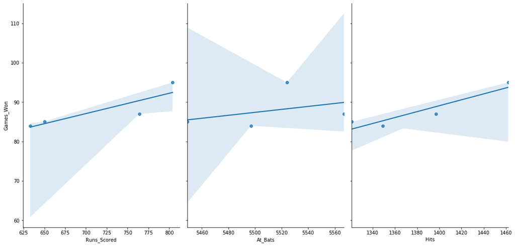

```python
sns.pairplot(New_York_Yankess1, x_vars=['Runs_Scored','At_Bats','Hits'], y_vars='Games_Won', height=7, aspect=0.7, kind='reg')
```

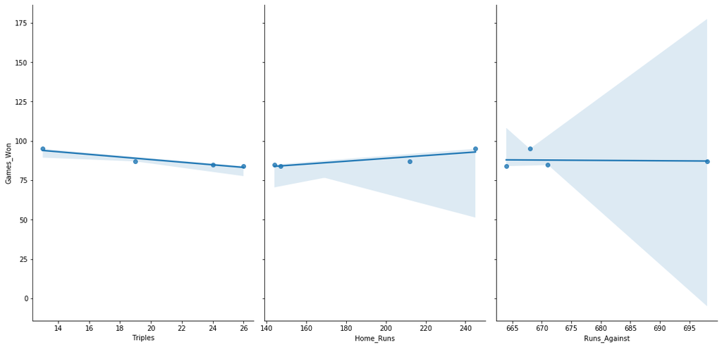

```python
sns.pairplot(New_York_Yankess1, x_vars=['Triples','Home_Runs','Runs_Against'], y_vars='Games_Won', height=7, aspect=0.7, kind='reg')
```

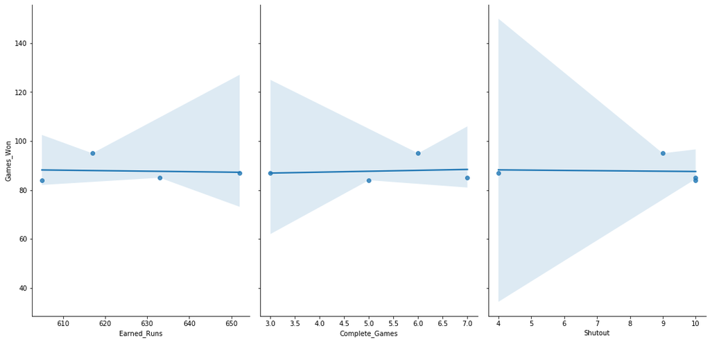

```python
sns.pairplot(New_York_Yankess1, x_vars=['Earned_Runs','Complete_Games','Shutout'], y_vars='Games_Won', height=7, aspect=0.7, kind='reg')
```

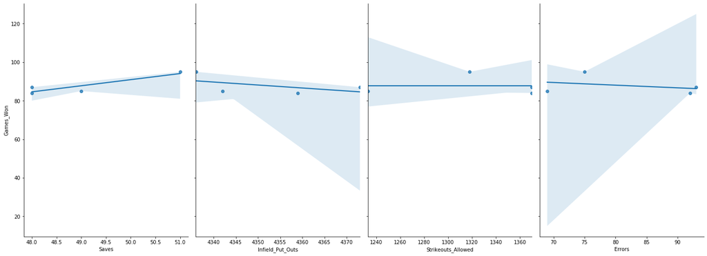

```python
sns.pairplot(New_York_Yankess1, x_vars=['Saves','Infield_Put_Outs','Strikeouts_Allowed','Errors'], y_vars='Games_Won', height=7, aspect=0.7, kind='reg')
```

**Model Evaluation Metrics for Regression**

```python
a=np.array(Game_won_prediction)
a
```

```
array([[98.],
       [82.],
       [81.],
       [88.]])
```

```python
b=np.array(New_York_Yankess1['Games_Won'])
b
```

```
array([95, 85, 84, 87], dtype=int64)
```

```python
print ('Root Mean Square Error (RMSE): ',np.sqrt(metrics.mean_squared_error(b,a)))
```

```
Root Mean Square Error (RMSE):  2.6457513110645907
```

*We can appreciate that the value for RMSE method is low , the differents between the real data and the prediction is small. In conclusion we can say that the model works very good with the selected variables*

**b) BLUE JAYS (2012 - 2015)**

**Prepare the Data for the Predictions**

```python
m2 = baseball_2012_2015['Team_Name'] == 'Toronto Blue Jays'
Toronto_Blue_Jays = baseball_2012_2015[m2]
Toronto_Blue_Jays
```

| Year | League | Team | Franchise | Division | Final_Standing | Games_Played | Unnamed: 7 | Games_Won | Games_Lost | Unnamed: 10 | Unnamed: 11 | League_Win | World_Series | Runs_Scored | At_Bats | Hits | Doubles | Triples | Home_Runs | Walks | Strike_Outs | Stolen_Bases | Caught_Stealing | Hit_By_Pitch | Sacrifice_Fly | Runs_Against | Earned_Runs | Earned_Run_Average | Complete_Games | … |
| --- | --- | --- | --- | --- | --- | --- | --- | --- | --- | --- | --- | --- | --- | --- | --- | --- | --- | --- | --- | --- | --- | --- | --- | --- | --- | --- | --- | --- | --- | --- |
| 2012 | AL | TOR | TOR | E | 4 | 162 | 81.0 | 73 | 89 | False | False | False | False | 716 | 5487 | 1346 | 247 | 22 | 198 | 473 | 1251.0 | 123.0 | 41.0 | 55.0 | 45.0 | 784 | 745 | 4.64 | 5 | … |
| 2013 | AL | TOR | TOR | E | 5 | 162 | 81.0 | 74 | 88 | False | False | False | False | 712 | 5537 | 1398 | 273 | 24 | 185 | 510 | 1123.0 | 112.0 | 41.0 | 38.0 | 38.0 | 756 | 685 | 4.25 | 4 | … |
| 2014 | AL | TOR | TOR | E | 3 | 162 | 81.0 | 83 | 79 | False | False | False | False | 723 | 5549 | 1435 | 282 | 24 | 177 | 502 | 1151.0 | 78.0 | 21.0 | 41.0 | 40.0 | 686 | 642 | 4.00 | 3 | … |
| 2015 | AL | TOR | TOR | E | 1 | 162 | 81.0 | 93 | 69 | True | False | False | False | 891 | 5509 | 1480 | 308 | 17 | 232 | 570 | 1151.0 | 88.0 | 23.0 | 54.0 | 62.0 | 670 | 609 | 3.80 | 7 | … |

```python
Toronto_Blue_Jays1=Toronto_Blue_Jays.drop(['League','Team ','Franchise ','Division','Final_Standing','Games_Played','Unnamed: 7','Games_Lost','Unnamed: 10','Unnamed: 11','League_Win','World_Series','Doubles','Walks','Strike_Outs','Stolen_Bases','Caught_Stealing','Hit_By_Pitch','Sacrifice_Fly','Earned_Run_Average','Hits_Allowed','Home_Run_Allowed','Walks_Allowed','Double_Plays','Fielding_Percentage','Team_Name','Home_Ball_Park','Attendance'],axis=1)
Toronto_Blue_Jays1
```

| Year | Games_Won | Runs_Scored | At_Bats | Hits | Triples | Home_Runs | Runs_Against | Earned_Runs | Complete_Games | Shutout | Saves | Infield_Put_Outs | Strikeouts_Allowed | Errors |
| --- | --- | --- | --- | --- | --- | --- | --- | --- | --- | --- | --- | --- | --- | --- |
| 2012 | 73 | 716 | 5487 | 1346 | 22 | 198 | 784 | 745 | 5 | 11 | 29 | 4331 | 1142 | 101 |
| 2013 | 74 | 712 | 5537 | 1398 | 24 | 185 | 756 | 685 | 4 | 11 | 39 | 4356 | 1208 | 111 |
| 2014 | 83 | 723 | 5549 | 1435 | 24 | 177 | 686 | 642 | 3 | 16 | 45 | 4329 | 1199 | 87 |
| 2015 | 93 | 891 | 5509 | 1480 | 17 | 232 | 670 | 609 | 7 | 10 | 34 | 4323 | 1117 | 88 |

**Create a prediction for Games Won in 2012, 2013, 2014 and 2015 for Toronto Blue Jays using the values of those years for the independent variables**

```python
def prediction(vec):
    var1 = vec[0]
    var2 = vec[1]
    var3 = vec[2]
    var4 = vec[3]
    var5 = vec[4]
    var6 = vec[5]
    var7 = vec[6]
    var8 = vec[7]
    var9 = vec[8]
    var10 = vec[9]
    var11 = vec[10]
    var12 = vec[11]
    var13 = vec[12]
    X = pd.DataFrame({'Runs_Scored': [var1], 'At_Bats':[var2], 'Hits':[var3], 'Triples':[var4], 'Home_Runs':[var5], 'Runs_Against':[var6], 'Earned_Runs':[var7], 'Complete_Games':[var8], 'Shutout':[var9], 'Saves':[var10], 'Infield_Put_Outs':[var11], 'Strikeouts_Allowed':[var12], 'Errors':[var13]})
    y = period42.predict(X)
    return y
Game_won_prediction =Toronto_Blue_Jays1[['Runs_Scored','At_Bats','Hits','Triples','Home_Runs','Runs_Against','Earned_Runs','Complete_Games','Shutout','Saves','Infield_Put_Outs','Strikeouts_Allowed','Errors']].apply(prediction, axis = 1)
```

```python
Game_won_prediction=round(Game_won_prediction )
Game_won_prediction
```

| Year | 0 |
| --- | --- |
| 2012 | 71.0 |
| 2013 | 78.0 |
| 2014 | 85.0 |
| 2015 | 98.0 |

```python
Toronto_Blue_Jays1['Game_won_prediction']=Game_won_prediction
Toronto_Blue_Jays1
```

| Year | Games_Won | Runs_Scored | At_Bats | Hits | Triples | Home_Runs | Runs_Against | Earned_Runs | Complete_Games | Shutout | Saves | Infield_Put_Outs | Strikeouts_Allowed | Errors | Game_won_prediction |
| --- | --- | --- | --- | --- | --- | --- | --- | --- | --- | --- | --- | --- | --- | --- | --- |
| 2012 | 73 | 716 | 5487 | 1346 | 22 | 198 | 784 | 745 | 5 | 11 | 29 | 4331 | 1142 | 101 | 71.0 |
| 2013 | 74 | 712 | 5537 | 1398 | 24 | 185 | 756 | 685 | 4 | 11 | 39 | 4356 | 1208 | 111 | 78.0 |
| 2014 | 83 | 723 | 5549 | 1435 | 24 | 177 | 686 | 642 | 3 | 16 | 45 | 4329 | 1199 | 87 | 85.0 |
| 2015 | 93 | 891 | 5509 | 1480 | 17 | 232 | 670 | 609 | 7 | 10 | 34 | 4323 | 1117 | 88 | 98.0 |

```python
Toronto_Blue_Jays1[['Games_Won','Game_won_prediction']]
```

| Year | Games_Won | Game_won_prediction |
| --- | --- | --- |
| 2012 | 73 | 71.0 |
| 2013 | 74 | 78.0 |
| 2014 | 83 | 85.0 |
| 2015 | 93 | 98.0 |

**Plotting the Least Squares Line**

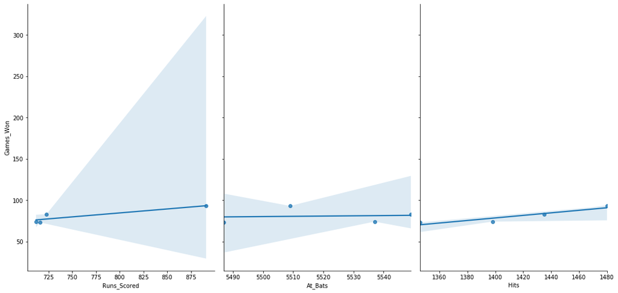

```python
sns.pairplot(Toronto_Blue_Jays1, x_vars=['Runs_Scored','At_Bats','Hits'], y_vars='Games_Won', height=7, aspect=0.7, kind='reg')
```

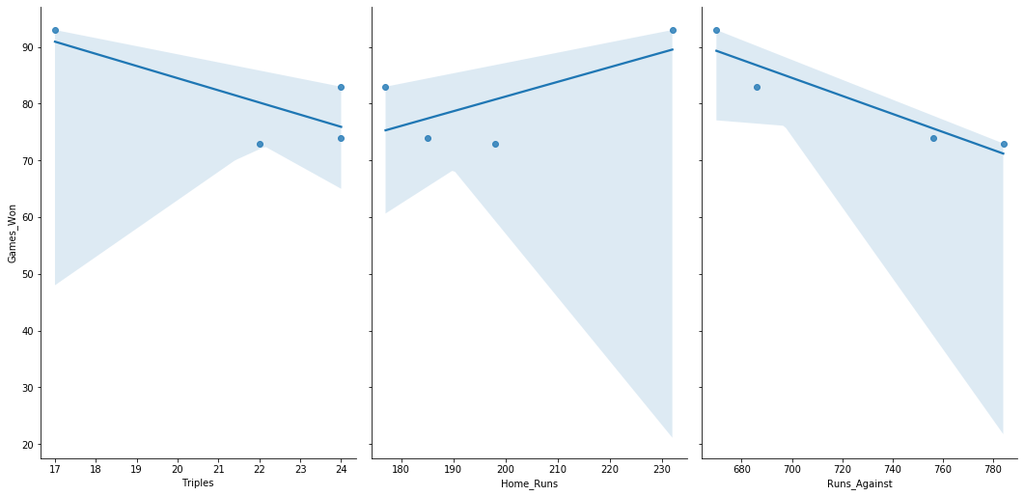

```python
sns.pairplot(Toronto_Blue_Jays1, x_vars=['Triples','Home_Runs','Runs_Against'], y_vars='Games_Won', height=7, aspect=0.7, kind='reg')
```

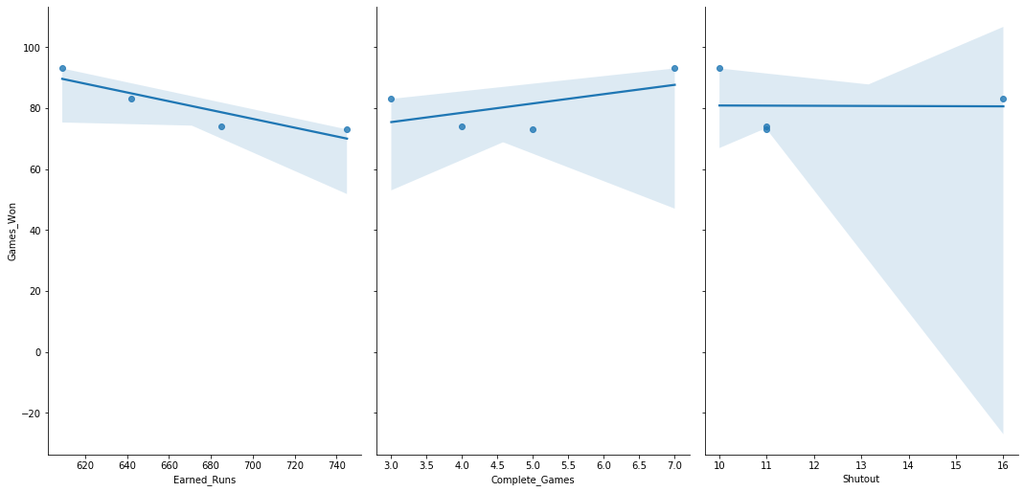

```python
sns.pairplot(Toronto_Blue_Jays1, x_vars=['Earned_Runs','Complete_Games','Shutout'], y_vars='Games_Won', height=7, aspect=0.7, kind='reg')
```

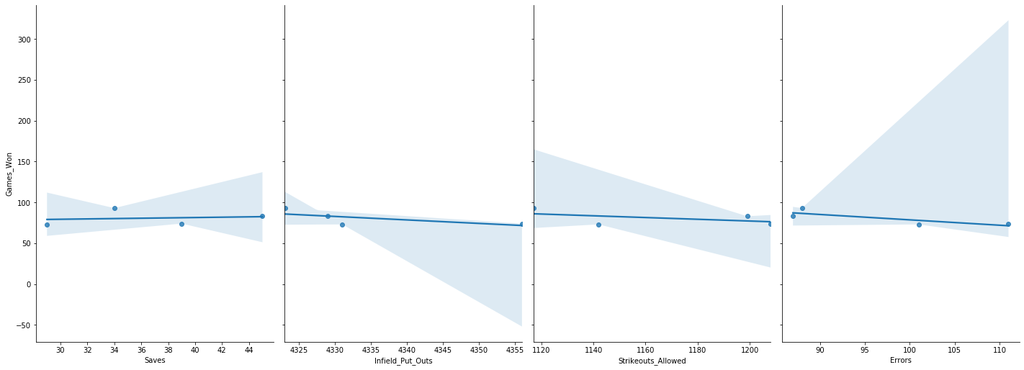

```python
sns.pairplot(Toronto_Blue_Jays1, x_vars=['Saves','Infield_Put_Outs','Strikeouts_Allowed','Errors'], y_vars='Games_Won', height=7, aspect=0.7, kind='reg')
```

**Model Evaluation Metrics for Regression**

```python
a=np.array(Game_won_prediction)
a
```

```
array([[71.],
       [78.],
       [85.],
       [98.]])
```

```python
b=np.array(Toronto_Blue_Jays1['Games_Won'])
b
```

```
array([73, 74, 83, 93], dtype=int64)
```

```python
print ('Root Mean Square Error (RMSE): ',np.sqrt(metrics.mean_squared_error(b,a)))
```

```
Root Mean Square Error (RMSE):  3.5
```

*We can appreciate that the value for RMSE method is quite low , the differents between the real data and predictions has a small difference, we should take into account that we have only four periods.*

## 7) CONCLUSIONS

The Goal of this project is determine what kind of strategy followed the most successful teams :

```
- High offenses
- Tight defenses
- Balance of two
```

Firts of all, we can see on the following graph the most successfuls Teams that won the World Series Tournament.

```python
World_series=baseball[baseball['World_Series'] == True]['Team_Name']
World_series
```

```
Year
1884        Providence Grays
1886        St. Louis Browns
1887      Detroit Wolverines
1888         New York Giants
1889         New York Giants
                ...
2011     St. Louis Cardinals
2012    San Francisco Giants
2013          Boston Red Sox
2014    San Francisco Giants
2015      Kansas City Royals
Name: Team_Name, Length: 116, dtype: object
```

```python
bb = World_series.value_counts()
bb
```

```
New York Yankees          27
St. Louis Cardinals       11
New York Giants            7
Boston Red Sox             7
Pittsburgh Pirates         5
Cincinnati Reds            5
Philadelphia Athletics     5
Los Angeles Dodgers        5
Detroit Tigers             4
Oakland Athletics          4
San Francisco Giants       3
Chicago White Sox          3
Baltimore Orioles          3
Cleveland Indians          2
Toronto Blue Jays          2
Chicago Cubs               2
Florida Marlins            2
Minnesota Twins            2
New York Mets              2
Kansas City Royals         2
Philadelphia Phillies      2
Brooklyn Dodgers           1
Providence Grays           1
Detroit Wolverines         1
Atlanta Braves             1
Milwaukee Braves           1
Washington Senators        1
Anaheim Angels             1
Arizona Diamondbacks       1
Boston Braves              1
St. Louis Browns           1
Boston Americans           1
Name: Team_Name, dtype: int64
```

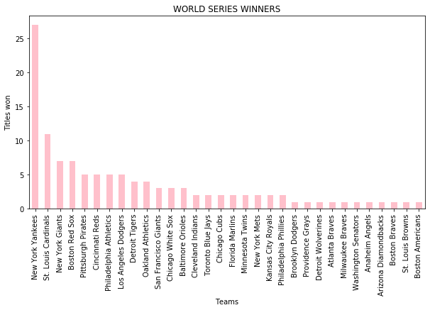

```python
bb.plot(kind = 'bar', figsize=(10,5), color = 'pink')
plt.title('WORLD SERIES WINNERS')
plt.ylabel('Titles won')
plt.xlabel('Teams')
```

New York Yankees is for far the most successful Team in baseball history. Through our Regression Model we can figure out what strategy the Team used to apply to be the Best of the Best.

According to our Model developed in Period four, we choose thirteen variables where the p-value is less than 0.05, the probability that this coefficients drop on zero is very low so, their contribution to the model is important. Between these variables we can recognize some of them are offensive tecniques and others are defensive tecniques.

The first conclusion we can deduce from here is that The Team (New York Yankees) use a combination of both strategies to be sucessful, High offenses and tight defenses.

We can analyze more deeply this strategy figuring out which proportion New York Yankees use these techniques.

Offenses tecniques

```
-Runs Scored
-At bats
-Hits
-Triples
-Home runs
```

TOTAL = 5

Defenses techniques

```
-Runs against
-Earned runs
-Complete games
-Shut outs
-Saves
-Infield put outs
-Strike outs allowed
-Errors
```

TOTAL = 8

```python
strate = {'Strategy': ['Offensives','Defensives'], 'Counts':[5,8]}
data = pd.DataFrame(strate)
data
```

|  | Strategy | Counts |
| --- | --- | --- |
| 0 | Offensives | 5 |
| 1 | Defensives | 8 |

```python
data = data.set_index('Strategy')
data
```

| Strategy | Counts |
| --- | --- |
| Offensives | 5 |
| Defensives | 8 |

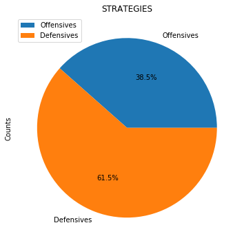

```python
data.plot(y="Counts", kind='pie',autopct='%1.1f%%',figsize=(16,6))
plt.title('STRATEGIES')
plt.legend(loc= 'upper left')
```

We can see on the graph that New York Yankees use 62% defensive strategies and 38% Offensive strategies. We can conclude that a successful team like New Yor Yankees use a balance of defensive and offensive strategy with more proportion in defensives techniques.